# Piglet Data Analysis

Elliot Teo

18 November 2019

# Introduction

## Stem cell project summary

This Rmarkdown document contains a basic descriptive analysis of the multiple data collected for our 8-day piglet model. The aim at the outset is to identify useful and non-useful data, identify trends and, where possible fit preliminary statistical models. Much of the data wrangling has been hidden for brevity.

## Experimental design

Large white piglets (n = 18) aged between 1 and 21 hours of age with body weight between 1.32kg and 2.18kg were used in this project. 7 animals died prior to experimental endpoint and were excluded from the numerical analysis, they have been left in some visualisations where indicated. Approval for this study was obtained from the University of Queensland Animal Experimentation Ethics Committee and was carried out according to the National Health and Medical Research Council guidelines (Australia). All animals used in this project fall under AEC Approval Number: UQCCR/215/18.

Piglets were given a hypoxic-ischaemic insult and allowed to recover. 2 hours later 250,000 stem cells were intravenously administered immedeatly prior to the comencement of hypothermia treatment. Hypothermia was maintained for 24 hours and animals were rewarmed over 10 hours. At the 36 hour time point animals were withdrawn from anaesthesia and recovered to 8 day. Animals were then euthanised and an autopsy was performed.

All investigators were blinded until date of analysis.

# Are our the two HI populations equivalent regarding on physical characteristics?

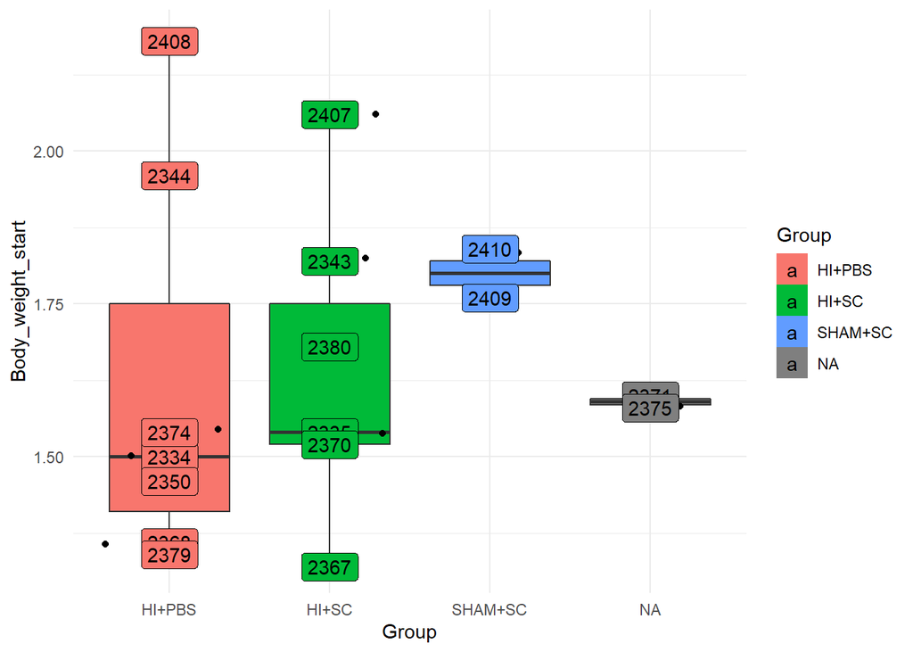

```r
print(Group_Weight)
```

Visual inspection of the graphs suggest that the group weights are similar. slightly larger range in the HI+PBS group. NA group reffers to animals that that died prior to treatment, thus suggesting that bodyweight is unrelated in these deaths.

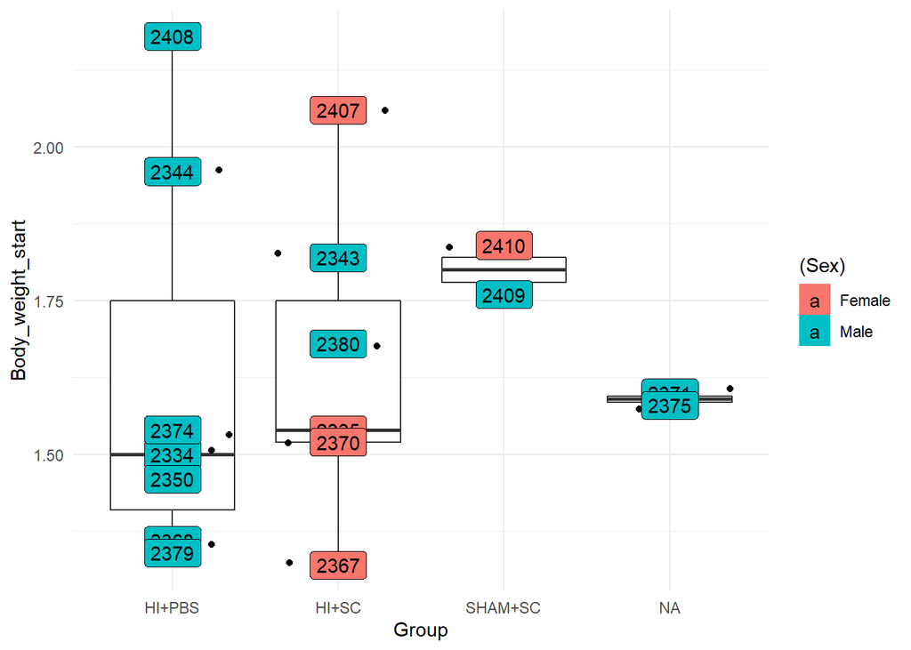

```r
print(Sex_Weight)
```

There does not appear to be any relationship between birthweights and sex, however it is clear that we have unbalanced groups with regards to sex. Males are more susptible to injury than females. This may influence the end brain outcomes between HI groups.

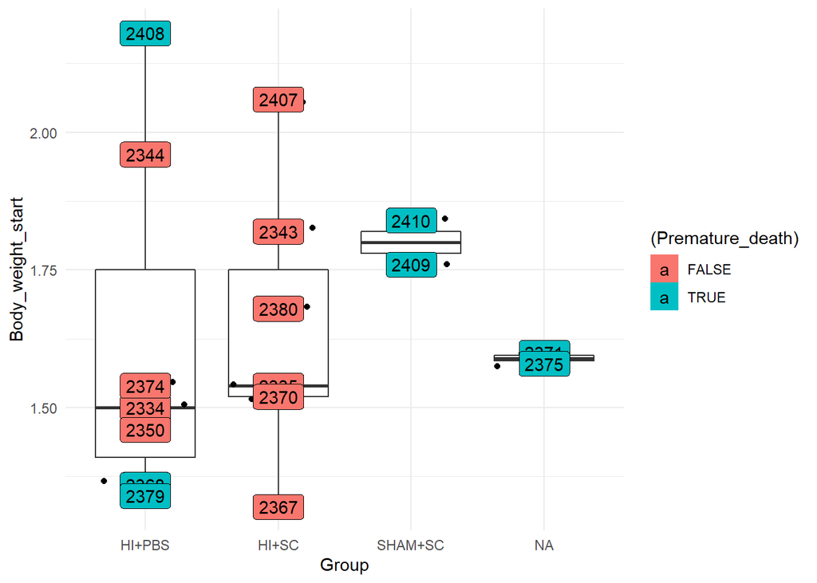

```r
print(Premature_death_Weight)
```

2379 and 2368 died with low body weights, it will be worth assessing there liver and brain weights. Low liver weight may be suggestive of IUGR injury in utero. It is unlikely that the other animals died due to weight related factors.

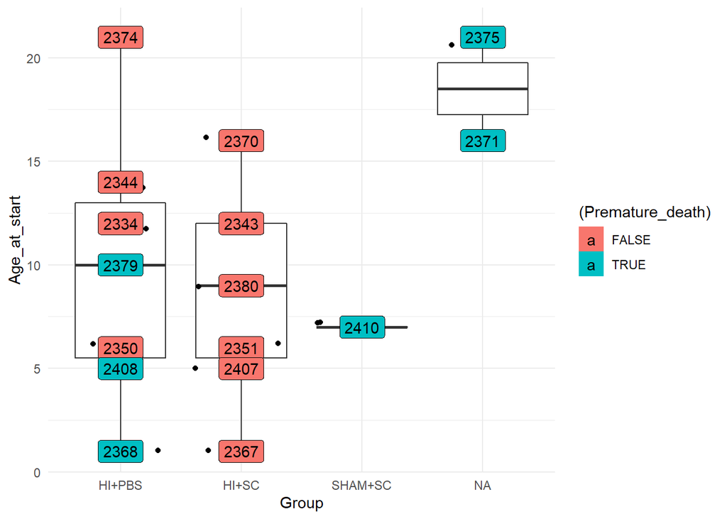

```r
print(Age_start)
```

It is unclear if death is related to their time at injury. However this graph clearly demonstrates a large difference in range. This is a weakness of our experimental model that could be addressed by beginning the experiment with a c-section.

```r
## Post mortem statistics

# Brain weight is heavier in the premature death group unsuprisingly. Additionally the missing brain weights belong to death piglets which could make this view more or less extreme
brain <- ggplot(HI_SC, aes(x=Group, y=Brain_weight, label = Pig))+
  geom_boxplot()+
  geom_label(aes(fill = Premature_death))

## 2379 has a very low liver weight and may suggest this piglet did not have optimal conditions in the womb.
liver <- ggplot(HI_SC, aes(x=Group, y=Liver_weight, label = Pig))+
  geom_boxplot()+
  geom_label(aes(fill = Premature_death))
## 2379 has a very low heart weight and may suggest this piglet did not have optimal conditions in the womb. 2374 may be a data input error
heart <- ggplot(HI_SC, aes(x=Group, y=Heart_weight, label = Pig))+
  geom_boxplot()+
  geom_label(aes(fill = Premature_death))

spleen <- ggplot(HI_SC, aes(x=Group, y=Spleen_weight, label = Pig))+
  geom_boxplot()+
  geom_label(aes(fill = Premature_death))
```

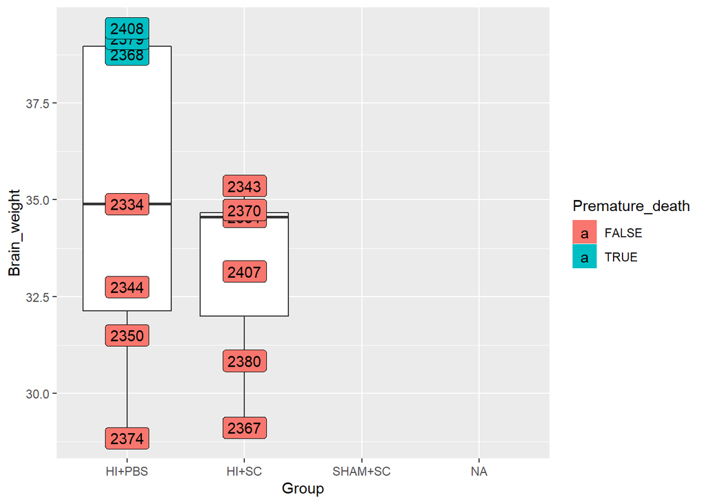

```r
print(brain)
```

Brain weight is heavier in the premature death group unsuprisingly. Additionally the missing brain weights belong to death piglets which could make this view more or less extreme

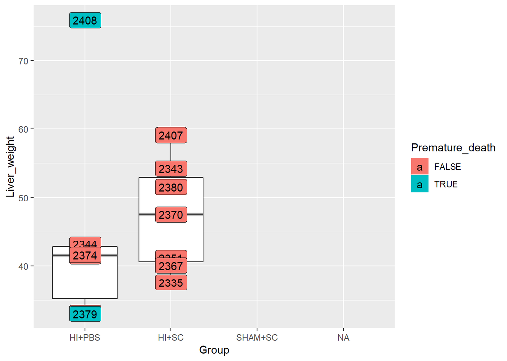

```r
print(liver)
```

2379 has a very low liver weight and may suggest this piglet did not have optimal conditions in the womb.

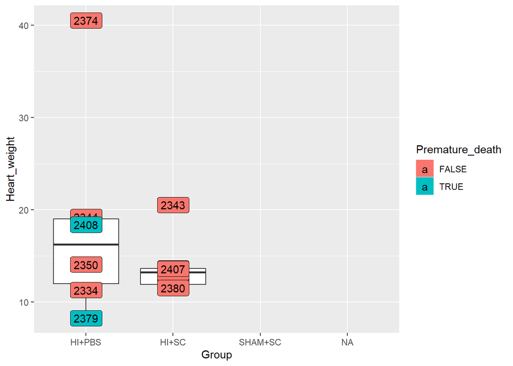

```r
print(heart)
```

2379 has a very low heart weight and may suggest this piglet did not have optimal conditions in the womb. 2374 may be a data input error.

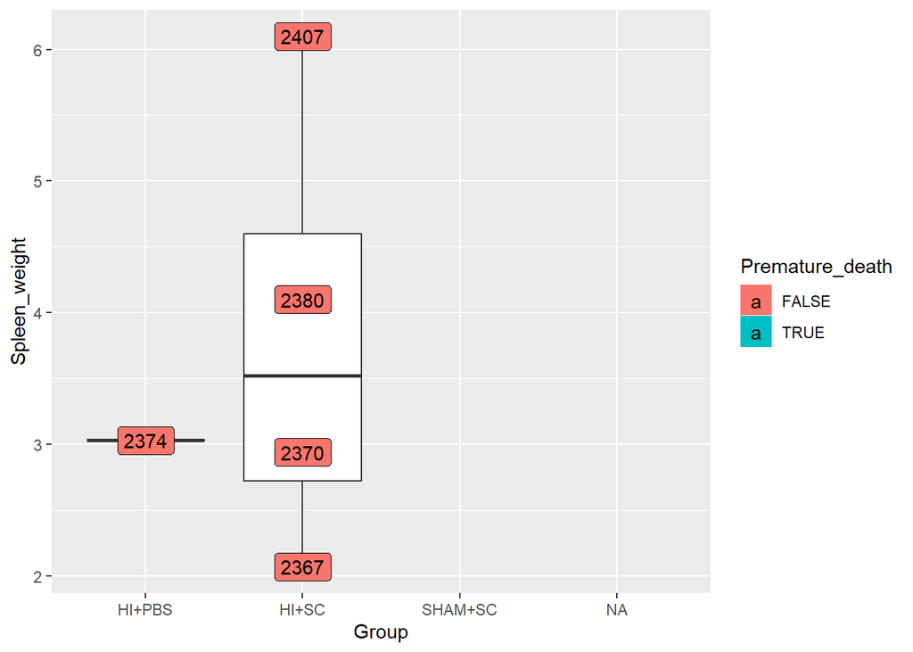

```r
print(spleen)
```

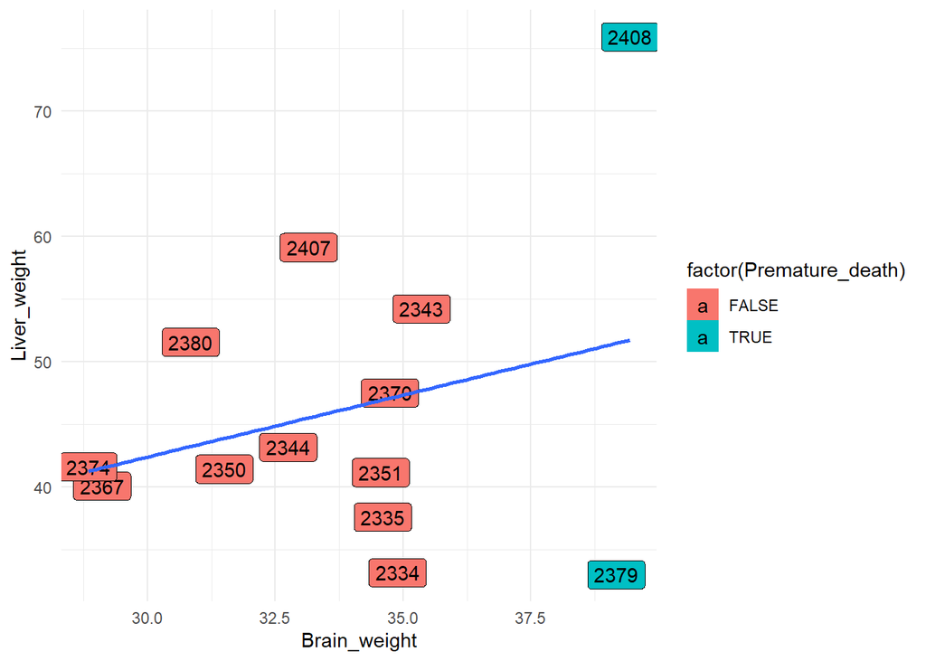

```r
#Brain-live ratios
brain_liver <- ggplot(HI_SC, aes(x=Brain_weight, y=Liver_weight, label = Pig))+
  geom_point()+
  geom_label(aes(fill = factor(Premature_death)))+
  geom_smooth(method = 'lm', se = FALSE)+
  theme_minimal()


print(brain_liver)
```

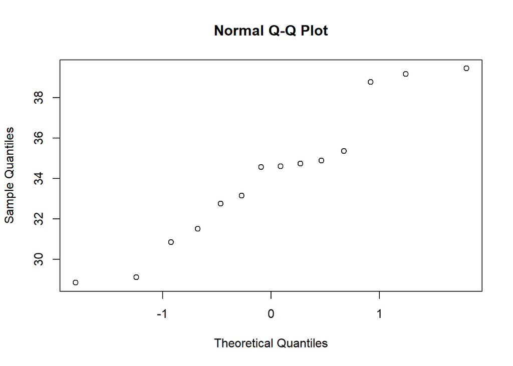

```r
# Because there is not enough data for the control group we will remove it
HI_SC_t.test <- HI_SC %>%
  filter(Group == "HI+PBS" | Group == "HI+SC")

qqnorm(HI_SC$Brain_weight)#equal variance
```

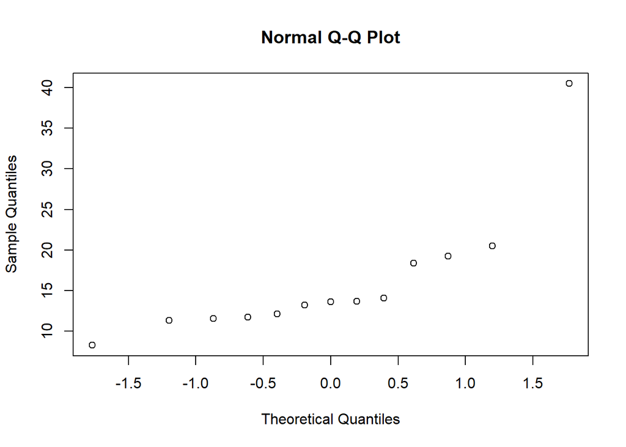

```r
qqnorm(HI_SC$Heart_weight)#unequal variance
```

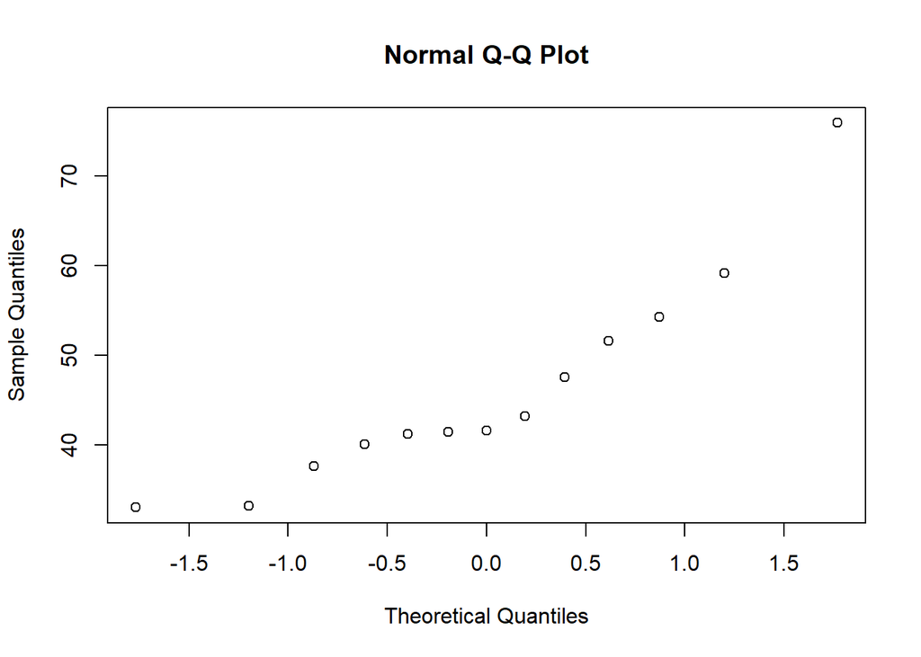

```r
qqnorm(HI_SC$Liver_weight)#unequal variance
```

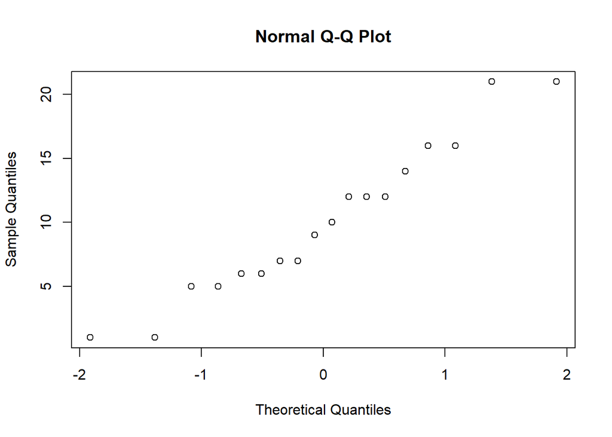

```r
qqnorm(HI_SC$Age_at_start)#equal variance
```

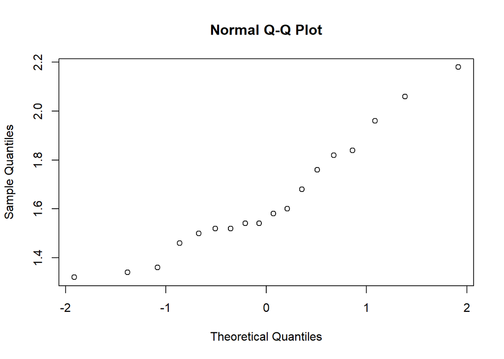

```r
qqnorm(HI_SC$Body_weight_start)#equal variance
```

```r
# With two groups we have unpaired two-sided T test with equal variance
base.multi.t.tests <-
    multi.tests(fun = t.test,
                df = HI_SC_t.test,
                vars = c("Age_at_start", "Brain_weight","Liver_weight","Heart_weight","Body_weight_start"),
                group.var = "Group",
                var.equal = TRUE)

# With two groups we have unpaired two-sided T test with unequal variance
base.multi.welch.t.tests <-
    multi.tests(fun = t.test,
                df = HI_SC_t.test,
                vars = c("Age_at_start", "Brain_weight","Liver_weight","Heart_weight","Body_weight_start"),
                group.var = "Group",
                var.equal = FALSE)

print(base.multi.t.tests)
```

```
## $Age_at_start
##
##  Two Sample t-test
##
## data:  Age_at_start by Group
## t = 0.36214, df = 12, p-value = 0.7235
## alternative hypothesis: true difference in means is not equal to 0
## 95 percent confidence interval:
##  -5.733078  8.018793
## sample estimates:
## mean in group HI+PBS  mean in group HI+SC
##             9.857143             8.714286
##
##
## $Brain_weight
##
##  Two Sample t-test
##
## data:  Brain_weight by Group
## t = 1.0177, df = 12, p-value = 0.3289
## alternative hypothesis: true difference in means is not equal to 0
## 95 percent confidence interval:
##  -2.117112  5.828540
## sample estimates:
## mean in group HI+PBS  mean in group HI+SC
##             35.05000             33.19429
##
##
## $Liver_weight
##
##  Two Sample t-test
##
## data:  Liver_weight by Group
## t = -0.38097, df = 11, p-value = 0.7105
## alternative hypothesis: true difference in means is not equal to 0
## 95 percent confidence interval:
##  -17.62283  12.42235
## sample estimates:
## mean in group HI+PBS  mean in group HI+SC
##             44.70833             47.30857
```

[output cut: 13 more lines]

```
##             18.61833             13.74857
##
##
## $Body_weight_start
##
##  Two Sample t-test
##
## data:  Body_weight_start by Group
## t = -0.11262, df = 12, p-value = 0.9122
## alternative hypothesis: true difference in means is not equal to 0
## 95 percent confidence interval:
##  -0.3487956  0.3145099
## sample estimates:
## mean in group HI+PBS  mean in group HI+SC
##             1.620000             1.637143
```

```r
print(base.multi.welch.t.tests)
```

```
## $Age_at_start
##
##  Welch Two Sample t-test
##
## data:  Age_at_start by Group
## t = 0.36214, df = 11.257, p-value = 0.724
## alternative hypothesis: true difference in means is not equal to 0
## 95 percent confidence interval:
##  -5.783720  8.069434
## sample estimates:
## mean in group HI+PBS  mean in group HI+SC
##             9.857143             8.714286
##
##
## $Brain_weight
##
##  Welch Two Sample t-test
##
## data:  Brain_weight by Group
## t = 1.0177, df = 9.4052, p-value = 0.3343
## alternative hypothesis: true difference in means is not equal to 0
## 95 percent confidence interval:
##  -2.242150  5.953579
## sample estimates:
## mean in group HI+PBS  mean in group HI+SC
##             35.05000             33.19429
##
##
## $Liver_weight
##
##  Welch Two Sample t-test
##
## data:  Liver_weight by Group
## t = -0.36241, df = 7.1503, p-value = 0.7275
## alternative hypothesis: true difference in means is not equal to 0
## 95 percent confidence interval:
##  -19.49396  14.29349
## sample estimates:
## mean in group HI+PBS  mean in group HI+SC
##             44.70833             47.30857
```

[output cut: 13 more lines]

```
##             18.61833             13.74857
##
##
## $Body_weight_start
##
##  Welch Two Sample t-test
##
## data:  Body_weight_start by Group
## t = -0.11262, df = 11.142, p-value = 0.9123
## alternative hypothesis: true difference in means is not equal to 0
## 95 percent confidence interval:
##  -0.3516506  0.3173649
## sample estimates:
## mean in group HI+PBS  mean in group HI+SC
##             1.620000             1.637143
```

The results of the t-tests demonstrate no difference between groups. We therefore conclude that we have homogenous groups across these factors.

Specifically: Group vs Age_at_start (p = 0.7235424 assuming equal variance: p = 0.7239518 assuming nonequal variance) Group vs Brain_weight (p = 0.3288883 assuming equal variance: p = 0.3342721 assuming nonequal variance) Group vs Liver_weight (p = 0.7104841 assuming equal variance: p = 0.72752 assuming nonequal variance) Group vs Heart_weight (p = 0.3025498 assuming equal variance: p = 0.3559416 assuming nonequal variance) Group vs Body weight (p = 0.9121931 assuming equal variance: p = 0.9123345 assuming nonequal variance)

So we can progress with the assumption that we are dealing with equivalent groups .

# Physiology

Next, we must be sure that we have sufficiently injured our HI group compared to control and that we are dealing with homogenous groups regarding injury severity.

### Aim

Aim 1: To establish statistical differences between control and HI groups and confirm homogenaity within the HI groups from the physiology data.

### Hypothesis

Hypothesis: There will be no difference between HI groups, and significant difference between HI and contol, at the end of HI that returns to normal at 4 hours post insult.

### Statistical methods

We will demonstrate no differences between control and HI piglets using a simple hypothesis test and kmeans clustering.

Method 1: T-Test

Method 2: kmeans clustering *The advantage of kmeans clustering is that it takes a multivariate approach and clusters based on euclidian distance within the feature space. This also gives us a method to see how the HI compare to the controls

```
## $pH
##
##  F test to compare two variances
##
## data:  pH by Group
## F = 0.19479, num df = 6, denom df = 6, p-value = 0.06686
## alternative hypothesis: true ratio of variances is not equal to 1
## 95 percent confidence interval:
##  0.03347057 1.13363385
## sample estimates:
## ratio of variances
##          0.1947906
##
##
## $ABE
##
##  F test to compare two variances
##
## data:  ABE by Group
## F = 0.64546, num df = 6, denom df = 6, p-value = 0.6083
## alternative hypothesis: true ratio of variances is not equal to 1
## 95 percent confidence interval:
##  0.1109076 3.7563925
## sample estimates:
## ratio of variances
##          0.6454553
##
##
## $HCO3
##
##  F test to compare two variances
##
## data:  HCO3 by Group
## F = 0.61483, num df = 6, denom df = 6, p-value = 0.5694
## alternative hypothesis: true ratio of variances is not equal to 1
## 95 percent confidence interval:
##  0.1056455 3.5781689
## sample estimates:
## ratio of variances
##          0.6148314
```

[output cut: 55 more lines]

```
##           1.614148
##
##
## $glu
##
##  F test to compare two variances
##
## data:  glu by Group
## F = 0.19374, num df = 6, denom df = 5, p-value = 0.07012
## alternative hypothesis: true ratio of variances is not equal to 1
## 95 percent confidence interval:
##  0.02776516 1.16001303
## sample estimates:
## ratio of variances
##           0.193737
```

```
## $pH
##
##  F test to compare two variances
##
## data:  pH by Group
## F = 1.6124, num df = 6, denom df = 6, p-value = 0.5763
## alternative hypothesis: true ratio of variances is not equal to 1
## 95 percent confidence interval:
##  0.2770621 9.3839749
## sample estimates:
## ratio of variances
##           1.612434
##
##
## $ABE
##
##  F test to compare two variances
##
## data:  ABE by Group
## F = 0.1985, num df = 6, denom df = 6, p-value = 0.06978
## alternative hypothesis: true ratio of variances is not equal to 1
## 95 percent confidence interval:
##  0.0341074 1.1552027
## sample estimates:
## ratio of variances
##          0.1984967
##
##
## $HCO3
##
##  F test to compare two variances
##
## data:  HCO3 by Group
## F = 2.5757, num df = 6, denom df = 6, p-value = 0.2745
## alternative hypothesis: true ratio of variances is not equal to 1
## 95 percent confidence interval:
##   0.4425824 14.9900753
## sample estimates:
## ratio of variances
##           2.575722
```

[output cut: 55 more lines]

```
##           1.134027
##
##
## $glu
##
##  F test to compare two variances
##
## data:  glu by Group
## F = 0.96099, num df = 6, denom df = 6, p-value = 0.9627
## alternative hypothesis: true ratio of variances is not equal to 1
## 95 percent confidence interval:
##  0.1651252 5.5927204
## sample estimates:
## ratio of variances
##          0.9609887
```

```
## $pH
##
##  Two Sample t-test
##
## data:  pH by Group
## t = -0.24132, df = 12, p-value = 0.8134
## alternative hypothesis: true difference in means is not equal to 0
## 95 percent confidence interval:
##  -0.08023086  0.06423086
## sample estimates:
## mean in group 1 mean in group 2
##        7.415714        7.423714
##
##
## $ABE
##
##  Two Sample t-test
##
## data:  ABE by Group
## t = 0.035904, df = 12, p-value = 0.9719
## alternative hypothesis: true difference in means is not equal to 0
## 95 percent confidence interval:
##  -2.557910  2.643624
## sample estimates:
## mean in group 1 mean in group 2
##        1.128571        1.085714
##
##
## $HCO3
##
##  Two Sample t-test
##
## data:  HCO3 by Group
## t = 0.026875, df = 12, p-value = 0.979
## alternative hypothesis: true difference in means is not equal to 0
## 95 percent confidence interval:
##  -2.287817  2.344960
## sample estimates:
## mean in group 1 mean in group 2
##        25.47143        25.44286
```

[output cut: 55 more lines]

```
##        96.42857       103.71429
##
##
## $glu
##
##  Two Sample t-test
##
## data:  glu by Group
## t = -0.15004, df = 11, p-value = 0.8834
## alternative hypothesis: true difference in means is not equal to 0
## 95 percent confidence interval:
##  -2.238471  1.952757
## sample estimates:
## mean in group 1 mean in group 2
##        5.357143        5.500000
```

```
## $pH
##
##  Two Sample t-test
##
## data:  pH by Group
## t = -0.69569, df = 12, p-value = 0.4999
## alternative hypothesis: true difference in means is not equal to 0
## 95 percent confidence interval:
##  -0.13103874  0.06761017
## sample estimates:
## mean in group 1 mean in group 2
##        7.070286        7.102000
##
##
## $ABE
##
##  Two Sample t-test
##
## data:  ABE by Group
## t = -1.1719, df = 12, p-value = 0.264
## alternative hypothesis: true difference in means is not equal to 0
## 95 percent confidence interval:
##  -14.867535   4.467535
## sample estimates:
## mean in group 1 mean in group 2
##       -15.21429       -10.01429
##
##
## $HCO3
##
##  Two Sample t-test
##
## data:  HCO3 by Group
## t = -0.21072, df = 12, p-value = 0.8366
## alternative hypothesis: true difference in means is not equal to 0
## 95 percent confidence interval:
##  -3.077942  2.535085
## sample estimates:
## mean in group 1 mean in group 2
##        11.94286        12.21429
```

[output cut: 55 more lines]

```
##        100.1429        113.4286
##
##
## $glu
##
##  Two Sample t-test
##
## data:  glu by Group
## t = -0.43065, df = 12, p-value = 0.6744
## alternative hypothesis: true difference in means is not equal to 0
## 95 percent confidence interval:
##  -3.722151  2.493580
## sample estimates:
## mean in group 1 mean in group 2
##        8.942857        9.557143
```

t.test results do not suggest a difference between the parameters associated with hypoxia, however there is a large yet statistically nonsignificant difference in the Hb which warrents investigation.

```r
## F test for assessment of equal variance

F.tHB <- var.test(tHB ~ Group, PrePhysTSend,
         alternative = "two.sided")

print(F.tHB) # if p>0.05 then there is no significant difference between the variances and they can be assumed to be equal.
```

```
##
##  F test to compare two variances
##
## data:  tHB by Group
## F = 1.134, num df = 6, denom df = 6, p-value = 0.8826
## alternative hypothesis: true ratio of variances is not equal to 1
## 95 percent confidence interval:
##  0.1948581 6.5997607
## sample estimates:
## ratio of variances
##           1.134027
```

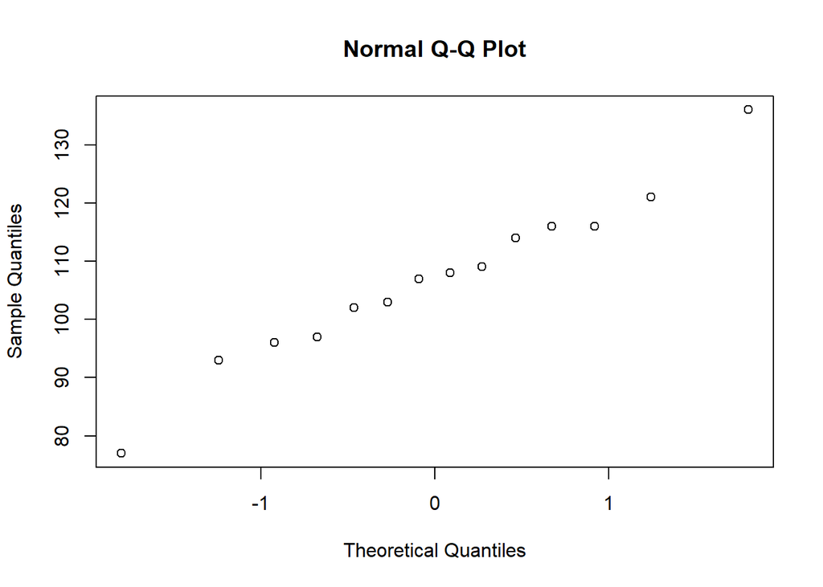

```r
qqnorm(PrePhysTSend$tHB)
```

```r
t.test.hb <- t.test(PrePhysTSend$tHB~PrePhysTSend$Group )

#plot(t.test.hb)
```

While the results of the tHB tests are not statistically significant, they are trending heavily. It is possible with if a population of pigs began with a low haemoglobin number they may be more suseptible to hypoxia.

```r
row.names(df_pre) <- Pig
row.names(df_post) <- Pig
```

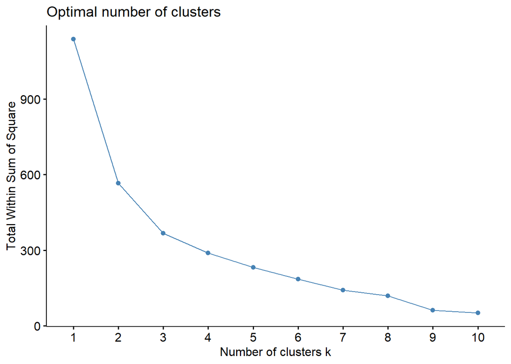

```r
#row.names(df_2) <- Pig
row.names(df_4) <- Pig

df_2 <- na.omit(df_2)

fviz_nbclust(df_pre, FUNcluster = kmeans, method = "wss", k.max = 10)
```

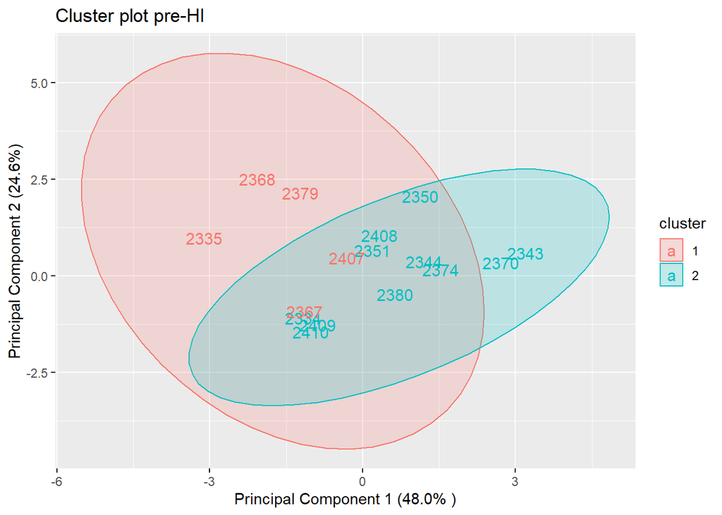

```r
Pre_kmeans <- kmeans(df_pre, centers = 2, iter.max = 10, nstart = 1)
fviz_cluster(Pre_kmeans, df_pre, geom = "text", main = "Cluster plot pre-HI", ellipse = TRUE, ellipse.type = "norm", show.clust.cent = FALSE, repel = FALSE, , xlab = "Principal Component 1 (48.0% )", ylab = "Principal Component 2 (24.6%)")
```

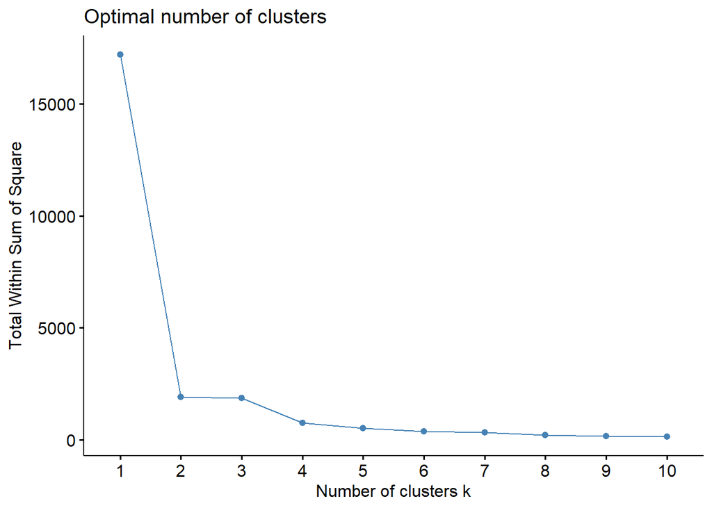

```r
fviz_nbclust(df_post, FUNcluster = kmeans, method = "wss", k.max = 10)
```

```
## Too few points to calculate an ellipse
```

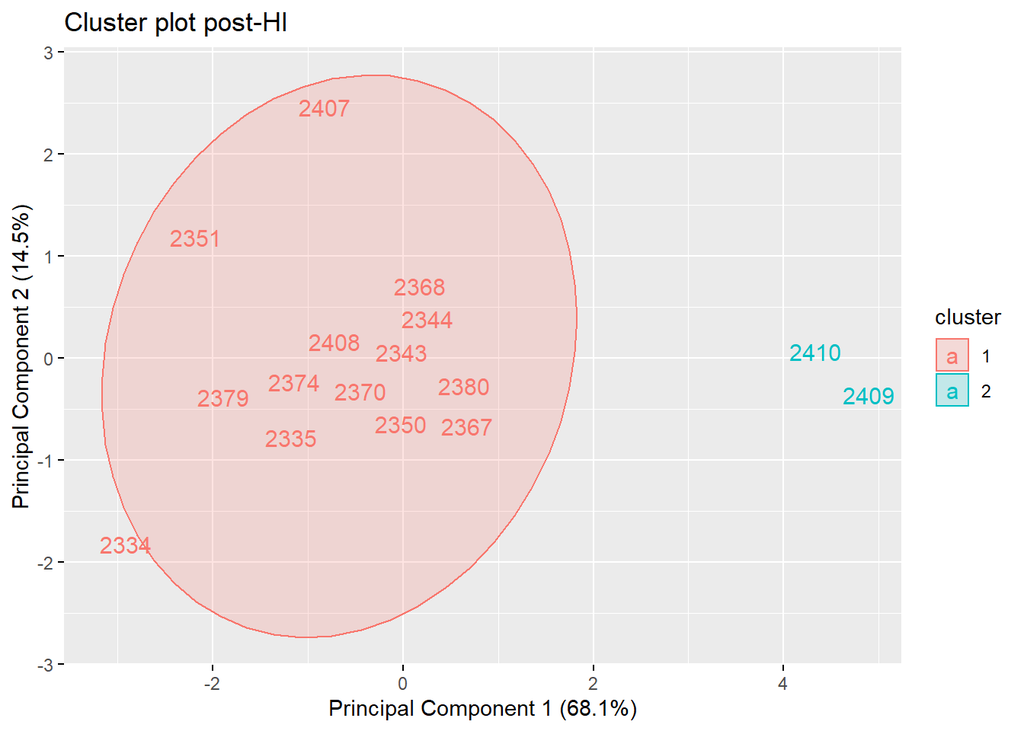

```r
Post_kmeans <-kmeans(df_post, centers = 2, iter.max = 10, nstart = 1)
fviz_cluster(Post_kmeans, df_post, geom = "text", main = "Cluster plot post-HI", ellipse = TRUE, ellipse.type = "norm", show.clust.cent = FALSE, repel = TRUE, xlab = "Principal Component 1 (68.1%)", ylab = "Principal Component 2 (14.5%)")
```

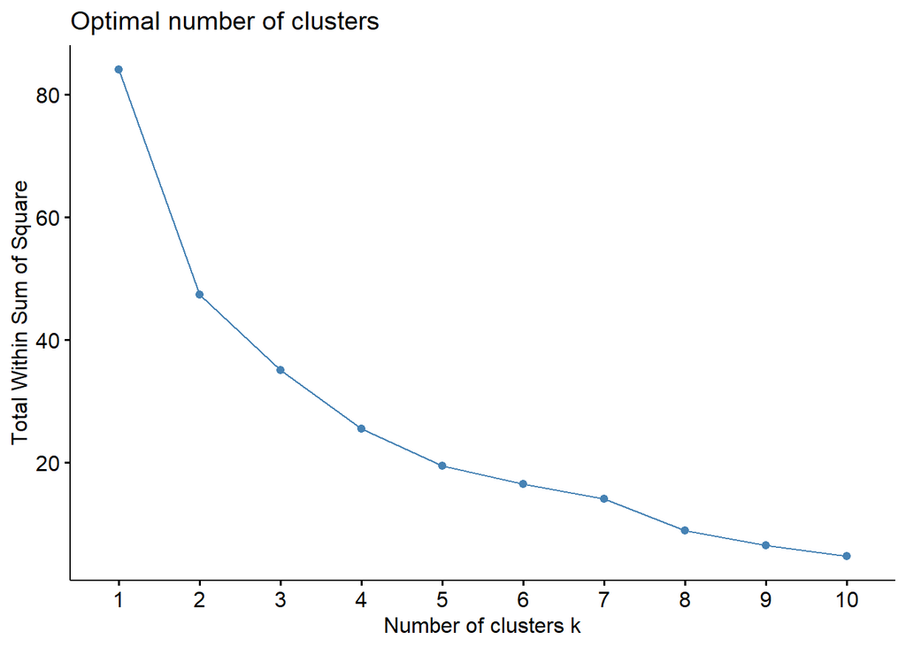

```r
fviz_nbclust(df_2, FUNcluster = kmeans, method = "wss", k.max = 10)
```

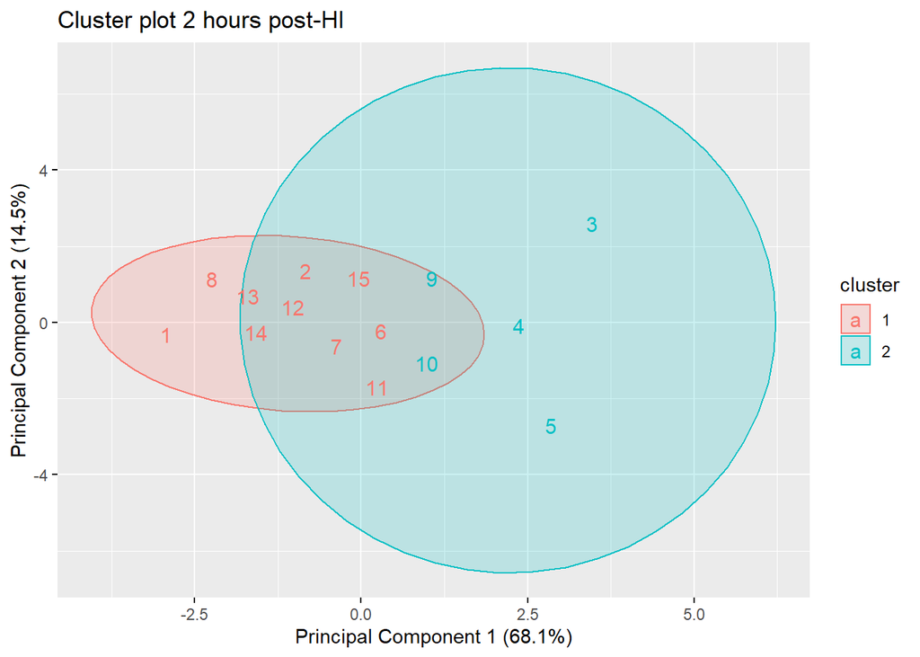

```r
Post_2_kmeans <-kmeans(df_2, centers = 2, iter.max = 10, nstart = 1)
fviz_cluster(Post_2_kmeans, df_2, geom = "text", main = "Cluster plot 2 hours post-HI", ellipse = TRUE, ellipse.type = "norm", show.clust.cent = FALSE, repel = TRUE, xlab = "Principal Component 1 (68.1%)", ylab = "Principal Component 2 (14.5%)")
```

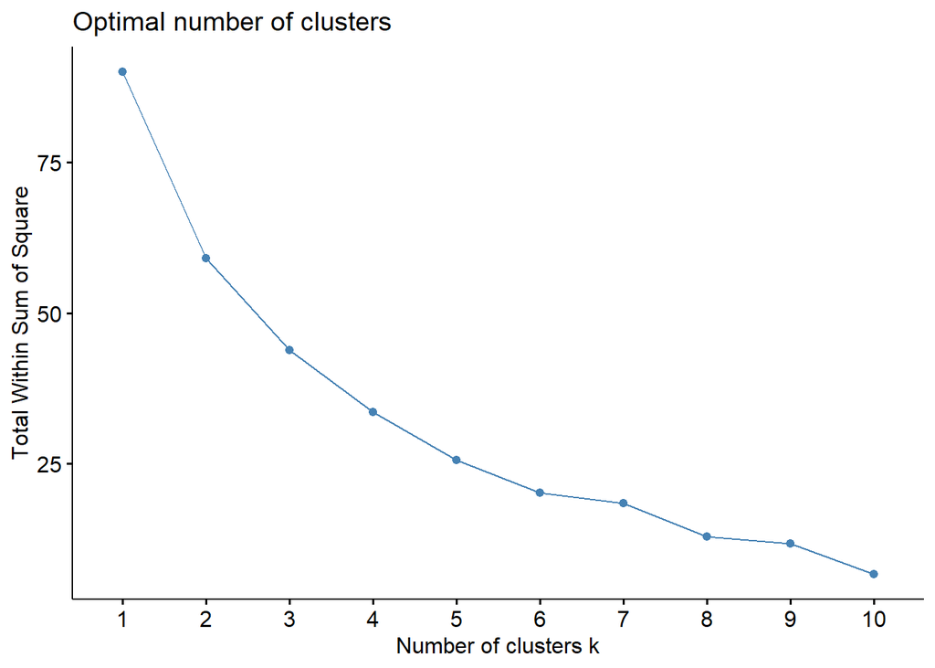

```r
fviz_nbclust(df_4, FUNcluster = kmeans, method = "wss", k.max = 10)
```

```
## Too few points to calculate an ellipse
```

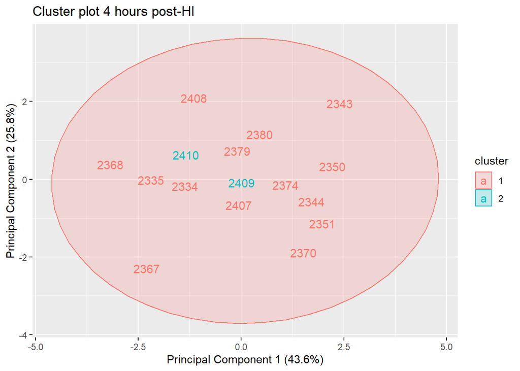

```r
Post_4_kmeans <-kmeans(df_post, centers = 2, iter.max = 10, nstart = 1)
fviz_cluster(Post_4_kmeans, df_4, geom = "text", main = "Cluster plot 4 hours post-HI", ellipse = TRUE, ellipse.type = "norm", show.clust.cent = FALSE, repel = TRUE,  xlab = "Principal Component 1 (43.6%)", ylab = "Principal Component 2 (25.8%)")
```

Clustering via kmeans is suggestive of 2 or three distinct clusters in the pre-HI plot and these are not separable according to their treatment groups. The second plot is highly suggestive of two distinct groups with the clusters totally separable. Plot number 3 suggests that by 4 hours there is no longer a difference between control and HI treated animals.

We can conclude from these data that there is a difference between control and HI treated animals, and no difference between the HI treated groups from the point of view of insult parameters.

Possible questions: What is Principal components analysis? It is the technique used to reduce the dimensionality of a dataset.

What are the steps to obtaining the principal components? 1. Take the whole dataset consisting of d+1 dimensions and ignore the labels such that our new dataset becomes d dimensional. 2. Compute the mean for every dimension of the whole dataset. 3. Compute the covariance matrix of the whole dataset. 4. Compute eigenvectors and the corresponding eigenvalues. 5. Sort the eigenvectors by decreasing eigenvalues and choose k eigenvectors with the largest eigenvalues to form a d × k dimensional matrix W. 6. Use this d × k eigenvector matrix to transform the samples onto the new subspace.

# Neurobehavioural Scoring

Now that we have established homogeneity between HI treated groups, we can ask if the treatment is having any effect on the neurobehavioural outcomes. Sham piglets were excluded from the analysis because they sucummed to unrelated adverse events.

```r
# The goal of this section is to clearly present the underlying relationships between variables and the correlation between measures in relation to the outcome variables.

HI_SC_NB <- read_excel("Copy of HI+SC_Piglet_master_file.xlsx", sheet = "Neurobehaviour_long", na = "NA")

##Rename groups
HI_SC_NB$Group[HI_SC_NB$Group == "3"] <- "SHAM+SC"
HI_SC_NB$Group[HI_SC_NB$Group == "2"] <- "HI+SC"
HI_SC_NB$Group[HI_SC_NB$Group == "1"] <- "HI+PBS"

# Coerce the appropriate columns to factor
f <- c("Premature_death", "Sex", "Group", "Litter", "Pig")
HI_SC_NB[f] <- lapply(HI_SC_NB[f], factor)

NB.Group <- HI_SC_NB %>%
  group_by(Group, Time)%>%
  na.omit()%>%
  mutate(Minimum  = min(Score), Mean =  mean(Score), Median = median(Score), Max =  max(Score), Standard.dev = sd(Score))
```

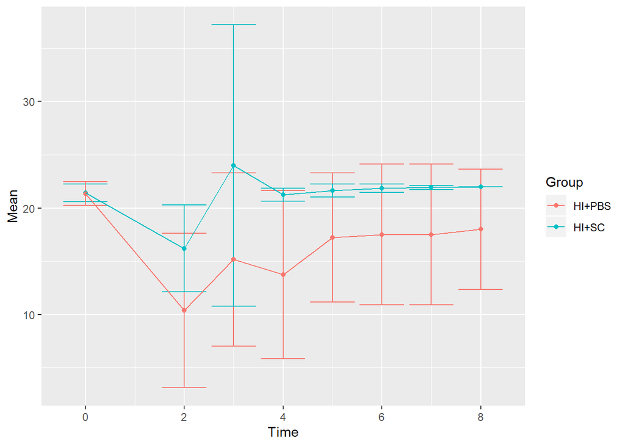

```r
NB.group.plot.mean <- ggplot(NB.Group, aes(x = Time, y = Mean, color = Group))+
  geom_errorbar(aes(ymin = Mean - Standard.dev, ymax = Mean+Standard.dev))+
  geom_point()+geom_line()

NB.group.plot.median <- ggplot(NB.Group, aes(x = Time, y = Median, color = Group))+
  geom_errorbar(aes(ymin = Median - Standard.dev, ymax = Median+Standard.dev))+
  geom_point()+geom_line()

print(NB.group.plot.mean)
```

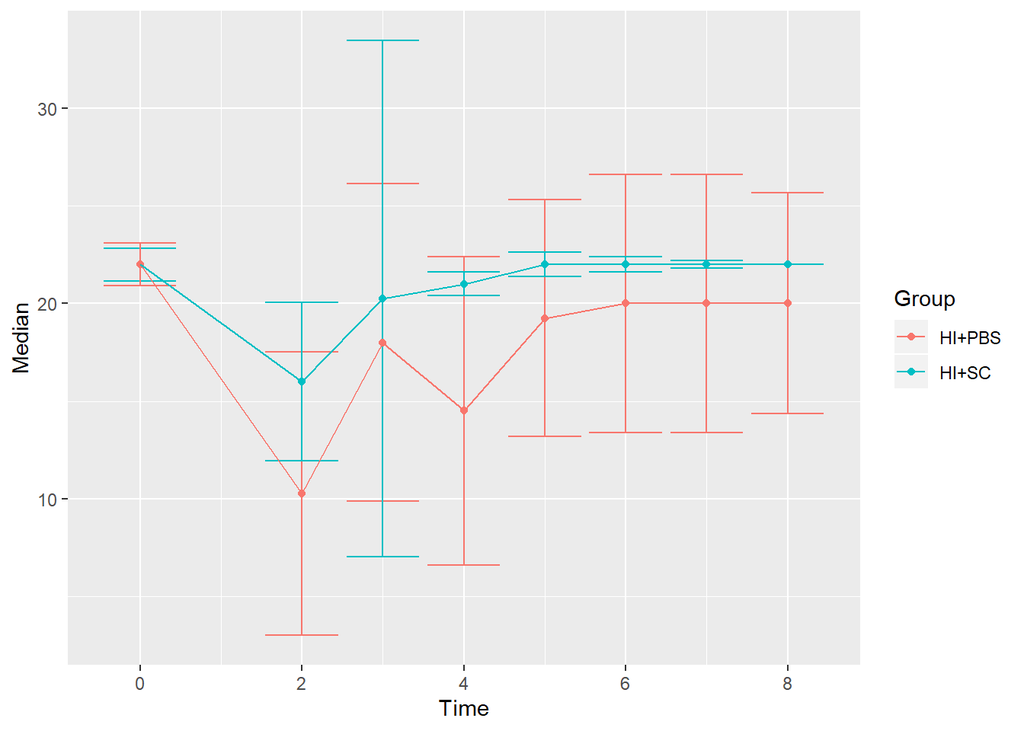

```r
print(NB.group.plot.median)
```

# EEG Analysis

```r
## EEG timeseries
EEG <- read_excel("Copy of HI+SC_Piglet_master_file.xlsx", sheet = "EEG_timeseries_rearrange", na = "NA")
```

```
## * `` -> ...21
```

```r
EEG <- EEG %>%
    filter(Group <= 2)%>%
    mutate(Score = as.numeric(Score))%>%
  mutate(Group = ifelse(Group == 1, "HI+PBS", "HI+SC"))%>%
  filter(Group == "HI+PBS" | Group == "HI+SC")%>%
    mutate(Group = factor(Group))

EEG.Group.Score <- EEG %>%
  group_by(Group, Time)%>%
  na.omit()%>%
  mutate(Minimum  =min(Score), Mean =  mean(Score), Median = median(Score), Max =  (Score), Standard.dev = sd(Score))

EEG.Group.M_AMP <- EEG %>%
  group_by(Group, Time)%>%
  na.omit()%>%
  mutate(Minimum  = (Min_L+Min_R)/2, Mean =  mean(M_AMP), Median = median(M_AMP), Max =  (Max_L+Max_R)/2, Standard.dev = sd(M_AMP))

print(EEG.Group.M_AMP)
```

```
## # A tibble: 282 x 26
## # Groups:   Group, Time [58]
##      Pig  Date Premature_death Sex   Group Litter Age_at_start Phase  Time
##    <dbl> <dbl> <lgl>           <chr> <fct>  <dbl>        <dbl> <chr> <dbl>
##  1  2334 43403 FALSE           MALE  HI+P~      1           12 HI        0
##  2  2335 43403 FALSE           FEMA~ HI+SC      1           12 HI        0
##  3  2343 43411 FALSE           MALE  HI+SC      2           12 HI        0
##  4  2344 43411 FALSE           MALE  HI+P~      2           14 HI        0
##  5  2350 43424 FALSE           MALE  HI+P~      3            6 HI        0
##  6  2351 43424 FALSE           MALE  HI+SC      3            6 HI        0
##  7  2368 43507 TRUE            MALE  HI+P~      4            1 HI        0
##  8  2374 43529 FALSE           MALE  HI+P~      6           21 HI        0
##  9  2380 43550 FALSE           MALE  HI+SC      7            9 HI        0
## 10  2407 43578 FALSE           FEMA~ HI+SC      8            5 HI        0
## # ... with 272 more rows, and 17 more variables: Max_L <dbl>, Min_L <dbl>,
## #   Amplitude_L <dbl>, Max_R <dbl>, Min_R <dbl>, Amplitude_R <dbl>,
## #   M_AMP <dbl>, Score <dbl>, SZ <chr>, BS <chr>, Temp_generated <dbl>,
## #   ...21 <chr>, Minimum <dbl>, Mean <dbl>, Median <dbl>, Max <dbl>,
## #   Standard.dev <dbl>
```

```r
print(EEG.Group.Score)
```

```
## # A tibble: 282 x 26
## # Groups:   Group, Time [58]
##      Pig  Date Premature_death Sex   Group Litter Age_at_start Phase  Time
##    <dbl> <dbl> <lgl>           <chr> <fct>  <dbl>        <dbl> <chr> <dbl>
##  1  2334 43403 FALSE           MALE  HI+P~      1           12 HI        0
##  2  2335 43403 FALSE           FEMA~ HI+SC      1           12 HI        0
##  3  2343 43411 FALSE           MALE  HI+SC      2           12 HI        0
##  4  2344 43411 FALSE           MALE  HI+P~      2           14 HI        0
##  5  2350 43424 FALSE           MALE  HI+P~      3            6 HI        0
##  6  2351 43424 FALSE           MALE  HI+SC      3            6 HI        0
##  7  2368 43507 TRUE            MALE  HI+P~      4            1 HI        0
##  8  2374 43529 FALSE           MALE  HI+P~      6           21 HI        0
##  9  2380 43550 FALSE           MALE  HI+SC      7            9 HI        0
## 10  2407 43578 FALSE           FEMA~ HI+SC      8            5 HI        0
## # ... with 272 more rows, and 17 more variables: Max_L <dbl>, Min_L <dbl>,
## #   Amplitude_L <dbl>, Max_R <dbl>, Min_R <dbl>, Amplitude_R <dbl>,
## #   M_AMP <dbl>, Score <dbl>, SZ <chr>, BS <chr>, Temp_generated <dbl>,
## #   ...21 <chr>, Minimum <dbl>, Mean <dbl>, Median <dbl>, Max <dbl>,
## #   Standard.dev <dbl>
```

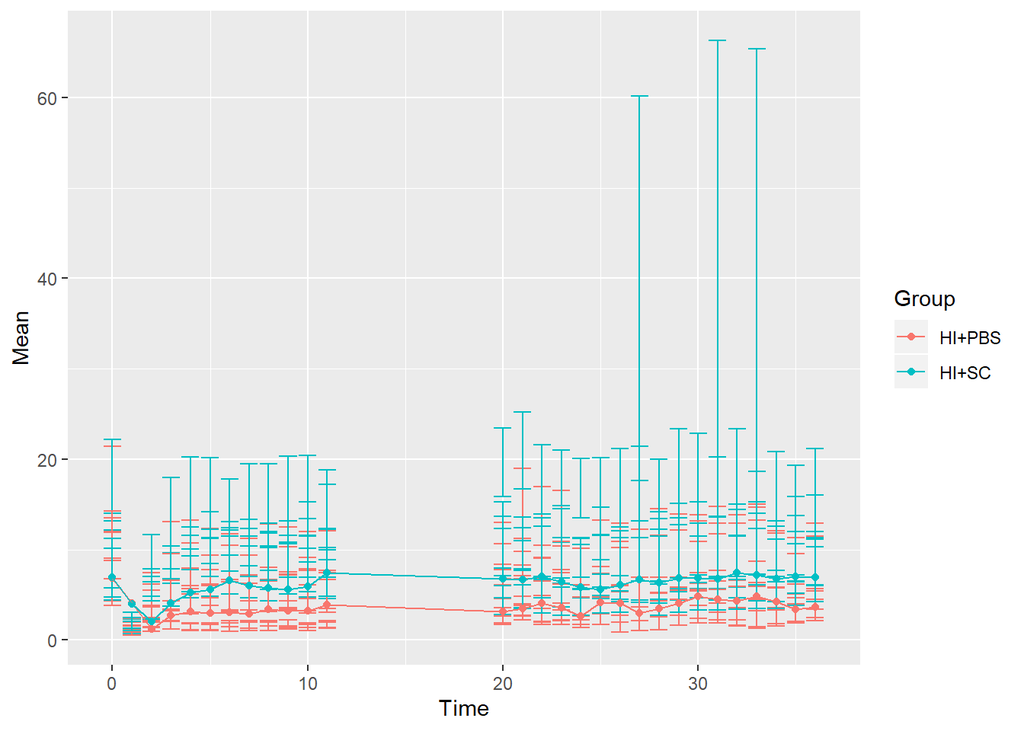

```r
ggplot(EEG.Group.M_AMP, aes(Time, Mean, color = Group ))+
  geom_errorbar(aes(ymin = Minimum, ymax = Max))+
  geom_point()+geom_line()
```

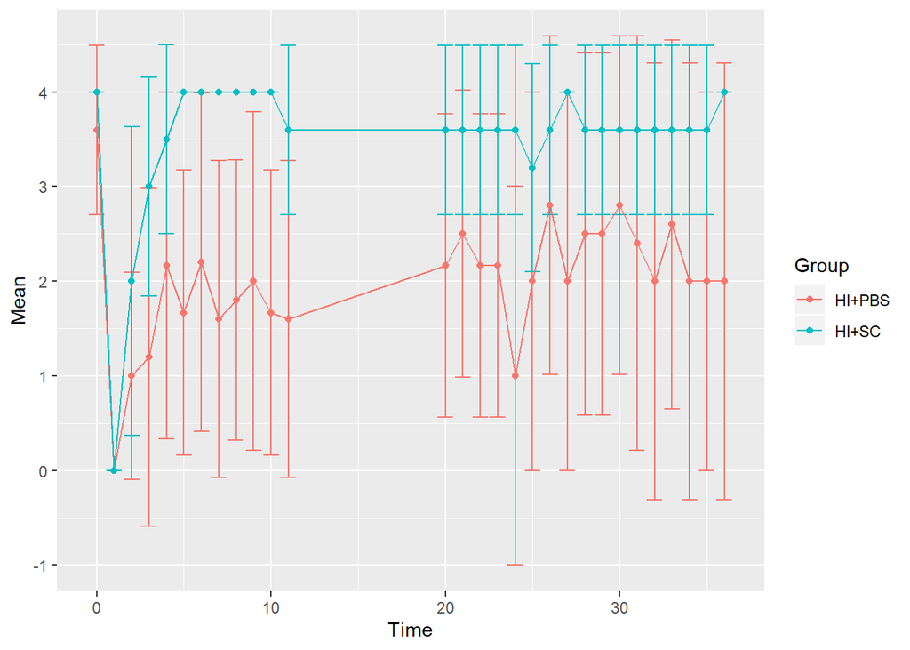

```r
ggplot(EEG.Group.Score, aes(Time, Mean, color = Group ))+
  geom_errorbar(aes(ymin = Mean - Standard.dev, ymax = Mean+Standard.dev))+
  geom_point()+geom_line()
```

# Microscopy Analysis

Now that we have established that there is a metabolic difference between the controls and the HI groups we can progress with analysis of brain outcomes. Conclusions will be drawn from multiple labels. NeuN to label neurons FJC to label degenerating neurons Caspase 3 to label apoptotic cells GFAP to label astrocytes CD34 to quantify angiogenesis IBA to quantify immune upregulation.

```r
## Microscopy data loading
Pig_char <- read_excel("Copy of HI+SC_Piglet_master_file.xlsx", sheet = "Microscopy", range ="A2:G435", na = "NA")
Pig_char$Group[Pig_char$Group == "3"] <- "SHAM+SC"
Pig_char$Group[Pig_char$Group == "2"] <- "HI+SC"
Pig_char$Group[Pig_char$Group == "1"] <- "HI+PBS"

Pig_char$Sex <- as.factor(Pig_char$Sex)
Pig_char$Premature_death <- as.factor(Pig_char$Premature_death)
Pig_char$Pig <- as.factor(Pig_char$Pig)
Pig_char$Group <- as.factor(Pig_char$Group)
Pig_char$Litter <- as.factor(Pig_char$Litter)
Pig_char$Region <- as.factor(Pig_char$Region)

NeuN <- read_excel("Copy of HI+SC_Piglet_master_file.xlsx", sheet = "Microscopy", range = "H2:K435", na = "NA")
FJC <- read_excel("Copy of HI+SC_Piglet_master_file.xlsx", sheet = "Microscopy", range = "L2:O435", na = "NA")
CAS3 <-read_excel("Copy of HI+SC_Piglet_master_file.xlsx", sheet = "Microscopy", range = "P2:S435", na = "NA")
GFAP <-read_excel("Copy of HI+SC_Piglet_master_file.xlsx", sheet = "Microscopy", range = "T2:W435", na = "NA")
MBP <-read_excel("Copy of HI+SC_Piglet_master_file.xlsx", sheet = "Microscopy", range = "X2:AA435", na = "NA")
CD34 <-read_excel("Copy of HI+SC_Piglet_master_file.xlsx", sheet = "Microscopy", range = "AB2:AE435", na = "NA")
Ki67 <-read_excel("Copy of HI+SC_Piglet_master_file.xlsx", sheet = "Microscopy", range = "AF2:AI435", na = "NA")
IBA <-read_excel("Copy of HI+SC_Piglet_master_file.xlsx", sheet = "Microscopy", range = "AJ2:AQ435", na = "NA")



# Join create new data frames by joining the Pig_char with each label data
NeuN <- cbind(Pig_char,NeuN)
FJC <- cbind(Pig_char,FJC)
CAS3 <- cbind(Pig_char,CAS3)
MBP <- cbind(Pig_char,MBP)
GFAP <- cbind(Pig_char,GFAP)
#Ki67 <- cbind(Pig_char,Ki67)
CD34 <- cbind(Pig_char,CD34)
IBA <- cbind(Pig_char,IBA)

# Remove unnecessary regions from the data
NeuN <-NeuN[!(NeuN$Region=="CA1"),]
CAS3 <-CAS3[!(CAS3$Region=="PVWM"),]
GFAP <-GFAP[!(GFAP$Region=="PVWM"),]
GFAP <-GFAP[!(GFAP$Region=="CA1"),]


# This block of code is to pull out only the HI treated animals as twe have not yet quantified the Controls
NeuN <- NeuN %>%
  filter(Group == "HI+SC" | Group == "HI+PBS")
FJC <- FJC %>%
  filter(Group == "HI+SC" | Group == "HI+PBS")
CAS3 <- CAS3 %>%
  filter(Group == "HI+SC" | Group == "HI+PBS")
MBP <- MBP %>%
  filter(Group == "HI+SC" | Group == "HI+PBS")
GFAP <- GFAP %>%
  filter(Group == "HI+SC" | Group == "HI+PBS")
CD34 <- CD34 %>%
  filter(Group == "HI+SC" | Group == "HI+PBS")
IBA <- IBA %>%
  filter(Group == "HI+SC" | Group == "HI+PBS")


# List create a list of all the histology data for conveiniece and looping abillity.
Microscopy <- list(NeuN,FJC,CAS3,MBP,GFAP,CD34)
Microscopyl <- c("NeuN","FJC","CAS3","MBP","GFAP","CD34") # l indicates lables

# Remove missing values from the data
for (i in seq_along(Microscopy)){
  Microscopy[[i]]<-na.omit(Microscopy[[i]])
}

# This function allows us to see the total spread of the individual data points and how they compare to the other pigs.
xMicroscopy = Microscopy

for (i in seq_along(xMicroscopy)){
  xMicroscopy[[i]] <- melt(xMicroscopy[[i]], id.vars = c("Pig", "Premature_death", "Sex", "Group", "Litter", "Region", "Field"), measure.vars = c("Run_1", "Run_2","Run_3"))

  #rename the variables
  xMicroscopy$value <- as.numeric(xMicroscopy[[i]]$value)

  i = i+1
}
```

[output not shown]

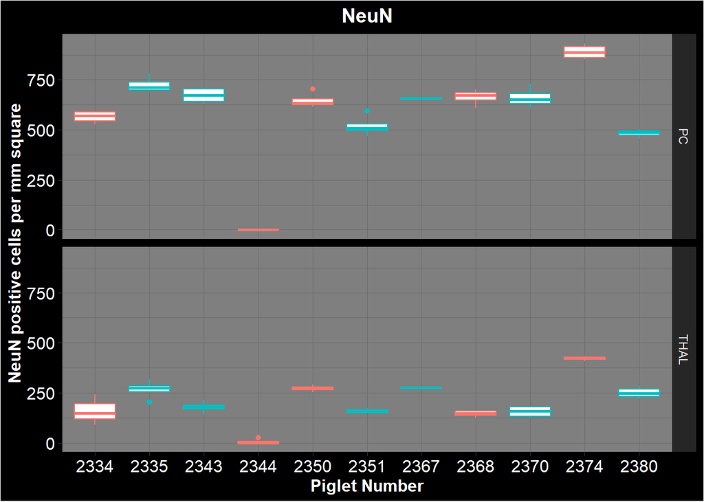

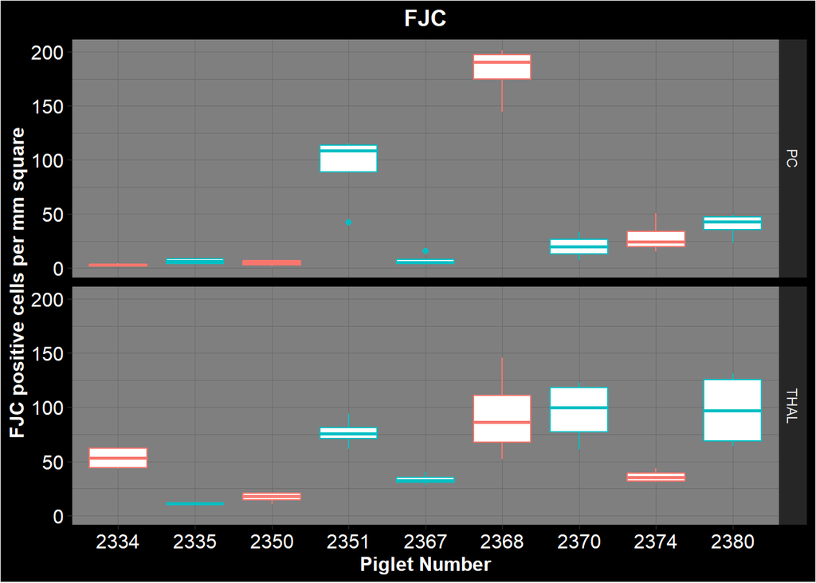

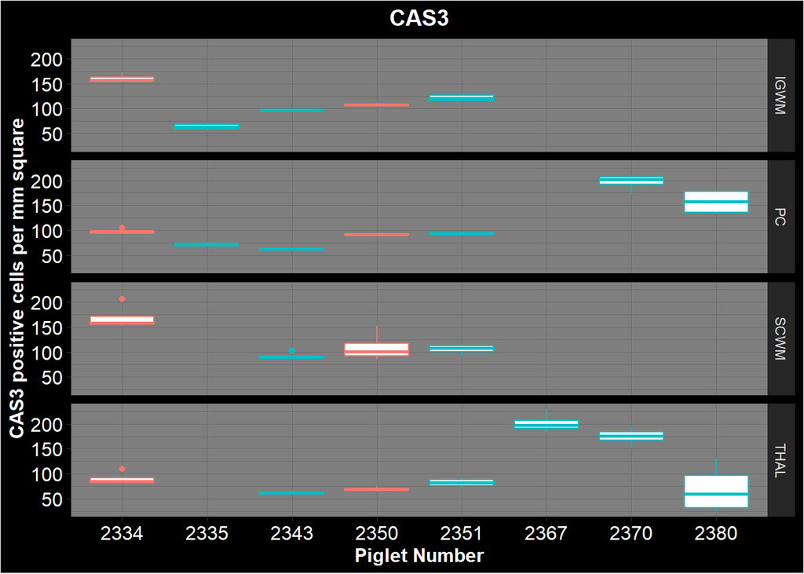

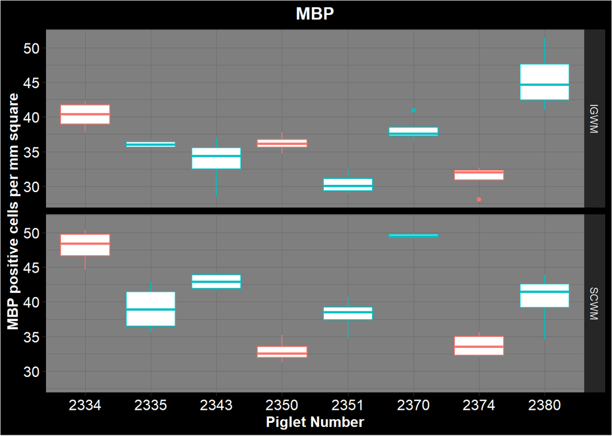

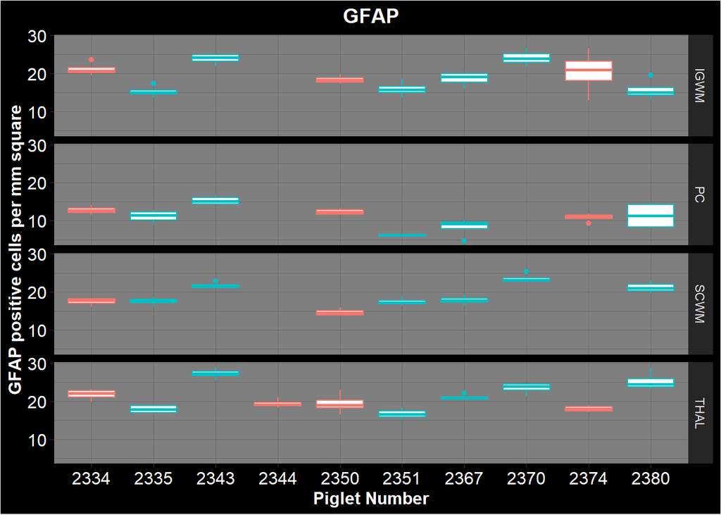

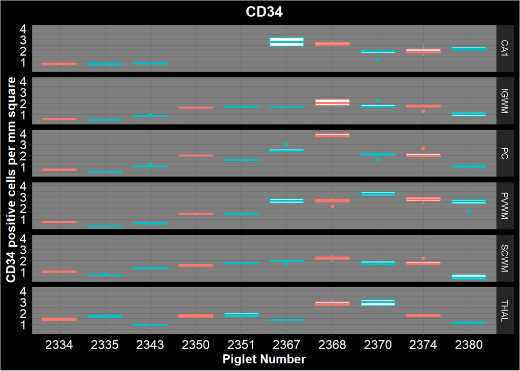

```r
# This function prints dotplots of the mean for each IHC/IF stain, and is separated by region
for (i in seq_along(Microscopy)){
  plot <- ggplot(Microscopy[[i]], aes( x = Microscopy[[i]]$Pig, y =Microscopy[[i]]$Mean, colour = Microscopy[[i]]$Group))+
    geom_boxplot()+
    ET_dark()+
    ggtitle(paste(Microscopyl[i]))+
    facet_grid(Microscopy[[i]]$Region)+
    ylab(paste(Microscopyl[i],'positive cells per mm square'))+
    xlab("Piglet Number")
  facet_wrap(Microscopy[[i]]$Region)

  print(plot)

  i = i+1

}
```

```r
# This function allows us to see the total spread of the individual data points and how they compare to the other pigs.
xMicroscopy = Microscopy

for (i in seq_along(xMicroscopy)){
  xMicroscopy[[i]] <- melt(xMicroscopy[[i]], id.vars = c("Pig", "Premature_death", "Sex", "Group", "Litter", "Region", "Field"), measure.vars = c("Run_1", "Run_2","Run_3"))

  #rename the variables
  xMicroscopy$value <- as.numeric(xMicroscopy[[i]]$value)

  i = i+1
}
```

[output not shown]

```r
# This function allows us to see the total spread of the individual data points and how they compare to the other pigs.
xMicroscopy = Microscopy

for (i in seq_along(xMicroscopy)){
  xMicroscopy[[i]] <- melt(xMicroscopy[[i]], id.vars = c("Pig", "Premature_death", "Sex", "Group", "Litter", "Region", "Field"), measure.vars = c("Run_1", "Run_2","Run_3"))
  #rename the variables
  xMicroscopy$value <- as.numeric(xMicroscopy[[i]]$value)

  i = i+1
}
```

[output not shown]

When we plot each plot individually we can see that the spread within piglets is small, though our spread between piglets is large. This may be due to the inconsistencies in rostro-caudal axis. We know there are large regional differences in the size of the individual neurons it would be expected that less large neurons would occupy a region occupied by small neurons.

```r
NeuN_melt <- melt(NeuN, id.vars = c("Pig", "Premature_death", "Sex", "Group", "Litter", "Region", "Field"), measure.vars = c("Run_1", "Run_2","Run_3"))
NeuN_summary <- NeuN_melt %>%
  group_by(Group, Region) %>%
  mutate(Cells_per_mm_2 = value)%>%
  na.omit(NeuN_melt)%>%
  summarise(min(Cells_per_mm_2), mean(Cells_per_mm_2), median(Cells_per_mm_2), max(Cells_per_mm_2), sd(Cells_per_mm_2))


GFAP_melt <- melt(GFAP, id.vars = c("Pig", "Premature_death", "Sex", "Group", "Litter", "Region", "Field"), measure.vars = c("Run_1", "Run_2","Run_3"))
GFAP_summary <- GFAP_melt %>%
  group_by(Group, Region) %>%
  mutate(Density = value)%>%
  na.omit(GFAP_melt)%>%
  summarise(min(Density), mean(Density), median(Density), max(Density), sd(Density))

CD34_melt <- melt(CD34, id.vars = c("Pig", "Premature_death", "Sex", "Group", "Litter", "Region", "Field"), measure.vars = c("Run_1", "Run_2","Run_3"))
CD34_summary <- CD34_melt %>%
  group_by(Group, Region) %>%
  mutate(Density = value)%>%
  na.omit(GFAP_melt)%>%
  summarise(min(Density), mean(Density), median(Density), max(Density), sd(Density))


MBP_melt <- melt(MBP, id.vars = c("Pig", "Premature_death", "Sex", "Group", "Litter", "Region", "Field"), measure.vars = c("Run_1", "Run_2","Run_3"))
MBP_summary <- MBP_melt %>%
  group_by(Group, Region) %>%
  mutate(Density = value)%>%
  na.omit(MBP_melt)%>%
  summarise(min(Density), mean(Density), median(Density), max(Density), sd(Density))


FJC_melt <- melt(FJC, id.vars = c("Pig", "Premature_death", "Sex", "Group", "Litter", "Region", "Field"), measure.vars = c("Run_1", "Run_2","Run_3"))
FJC_summary <- FJC_melt %>%
  group_by(Group, Region) %>%
  mutate(Cells_per_mm_2 = value)%>%
  na.omit(FJC_melt)%>%
  summarise(min(Cells_per_mm_2), mean(Cells_per_mm_2), median(Cells_per_mm_2), max(Cells_per_mm_2), sd(Cells_per_mm_2))

CAS3_melt <- melt(CAS3, id.vars = c("Pig", "Premature_death", "Sex", "Group", "Litter", "Region", "Field"), measure.vars = c("Run_1", "Run_2","Run_3"))
CAS3_summary <- CAS3_melt %>%
  group_by(Group, Region) %>%
  mutate(Cells_per_mm_2 = value)%>%
  na.omit(CAS3_melt)%>%
  summarise(min(Cells_per_mm_2), mean(Cells_per_mm_2), median(Cells_per_mm_2), max(Cells_per_mm_2), sd(Cells_per_mm_2))

FJC_transform <- CAS3_melt %>%
  mutate(log_val = log(value))

print(NeuN_summary)
```

```
## # A tibble: 4 x 7
## # Groups:   Group [2]
##   Group Region `min(Cells_per_~ `mean(Cells_per~ `median(Cells_p~
##   <fct> <fct>             <dbl>            <dbl>            <dbl>
## 1 HI+P~ PC                  0               553.             610.
## 2 HI+P~ THAL                0               203.             176.
## 3 HI+SC PC                301.              619.             661.
## 4 HI+SC THAL               28.0             214.             197.
## # ... with 2 more variables: `max(Cells_per_mm_2)` <dbl>,
## #   `sd(Cells_per_mm_2)` <dbl>
```

```r
print(FJC_summary)
```

```
## # A tibble: 5 x 7
## # Groups:   Group [2]
##   Group Region `min(Cells_per_~ `mean(Cells_per~ `median(Cells_p~
##   <fct> <fct>             <dbl>            <dbl>            <dbl>
## 1 HI+P~ PC                    0             54.5             10.3
## 2 HI+P~ THAL                  0             49.6             47.2
## 3 HI+SC CA1                   0             27.0             21.5
## 4 HI+SC PC                    0             34.4             15.4
## 5 HI+SC THAL                  0             66.4             36.0
## # ... with 2 more variables: `max(Cells_per_mm_2)` <dbl>,
## #   `sd(Cells_per_mm_2)` <dbl>
```

```r
print(CAS3_summary)
```

```
## # A tibble: 8 x 7
## # Groups:   Group [2]
##   Group Region `min(Cells_per_~ `mean(Cells_per~ `median(Cells_p~
##   <fct> <fct>             <dbl>            <dbl>            <dbl>
## 1 HI+P~ IGWM               78.2            136.             108.
## 2 HI+P~ PC                 54.3            102.              93.4
## 3 HI+P~ SCWM               60.7            139.              93.8
## 4 HI+P~ THAL               45.7             82.5             71.6
## 5 HI+SC IGWM               43.9             94.3             92.3
## 6 HI+SC PC                 40.3            134.             129.
## 7 HI+SC SCWM               57.3             96.2             89.2
## 8 HI+SC THAL               13.7            117.              90.4
## # ... with 2 more variables: `max(Cells_per_mm_2)` <dbl>,
## #   `sd(Cells_per_mm_2)` <dbl>
```

```r
print(GFAP_summary)
```

```
## # A tibble: 8 x 7
## # Groups:   Group [2]
##   Group Region `min(Density)` `mean(Density)` `median(Density~
##   <fct> <fct>           <dbl>           <dbl>            <dbl>
## 1 HI+P~ IGWM             9.23            20.0             18.8
## 2 HI+P~ PC               6.22            12.0             11.7
## 3 HI+P~ SCWM            10.8             16.0             16.3
## 4 HI+P~ THAL            14.1             19.6             18.6
## 5 HI+SC IGWM            10.4             18.9             17.8
## 6 HI+SC PC               1.06            10.6             11.1
## 7 HI+SC SCWM            12.0             19.9             18.9
## 8 HI+SC THAL            11.6             21.9             21.5
## # ... with 2 more variables: `max(Density)` <dbl>, `sd(Density)` <dbl>
```

```r
print(MBP_summary)
```

```
## # A tibble: 5 x 7
## # Groups:   Group [2]
##   Group Region `min(Density)` `mean(Density)` `median(Density~
##   <fct> <fct>           <dbl>           <dbl>            <dbl>
## 1 HI+P~ IGWM            21.1            35.9             35.3
## 2 HI+P~ PVWM             3.35            8.62             9.38
## 3 HI+P~ SCWM            27.0            38.2             34.9
## 4 HI+SC IGWM            22.4            36.6             37.0
## 5 HI+SC SCWM            28.6            42.8             42.8
## # ... with 2 more variables: `max(Density)` <dbl>, `sd(Density)` <dbl>
```

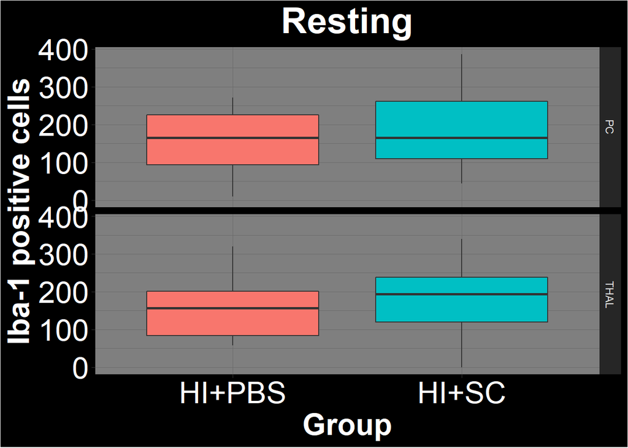

```r
for (i in seq_along(IBA)){
  IBA <-na.omit(IBA)
}


plot <- ggplot(IBA, aes(y = IBA$Ramified_Mean, x = IBA$Group))+
  geom_boxplot(aes(fill = IBA$Group))+
  theme_dark()+
  theme(axis.text=element_text(size=24, colour = "white"),
        axis.title=element_text(size=24,face="bold", colour = "white"),
        title=element_text(size=24,face="bold", colour = "white"),
        legend.text=element_text(size=24, colour = "white"),
        strip.text.x = element_text(size = 22),
        legend.key.height=unit(3,"line"), plot.title = element_text(hjust = 0.5)
        , plot.background = element_rect(fill = "black"), legend.position = "none")+
  #geom_jitter(color = xMicroscopy[[i]]$Pig)+
  ggtitle(paste('Resting'))+
  ylab("Iba-1 positive cells")+
  xlab("Group")+
  facet_grid(IBA$Region)

print(plot)
```

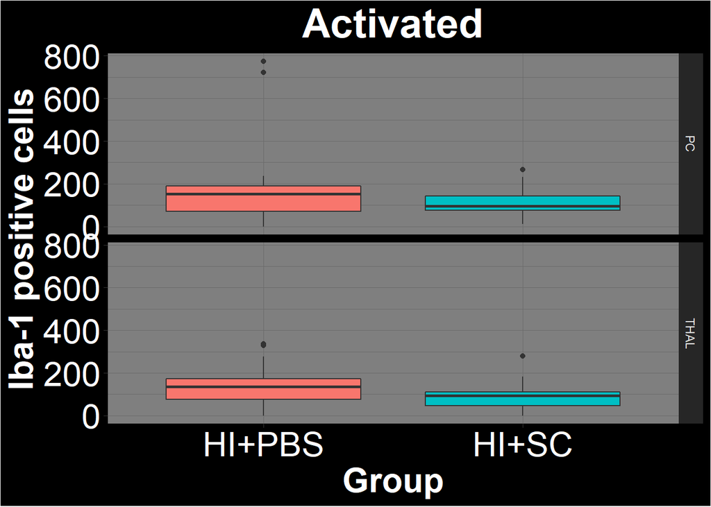

```r
plot <- ggplot(IBA, aes(y = IBA$Amoeboid_Mean, x = IBA$Group))+
  geom_boxplot(aes(fill = IBA$Group))+
  theme_dark()+
  theme(axis.text=element_text(size=24, colour = "white"),
        axis.title=element_text(size=24,face="bold", colour = "white"),
        title=element_text(size=24,face="bold", colour = "white"),
        legend.text=element_text(size=24, colour = "white"),
        strip.text.x = element_text(size = 22),
        legend.key.height=unit(3,"line"), plot.title = element_text(hjust = 0.5)
        , plot.background = element_rect(fill = "black"), legend.position = "none")+
  #geom_jitter(color = xMicroscopy[[i]]$Pig)+
  ggtitle(paste('Activated'))+
  ylab("Iba-1 positive cells")+
  xlab("Group")+
  facet_grid(IBA$Region)

print(plot)
```

```r
xIBA <- melt(IBA, id.vars = c("Pig", "Premature_death", "Sex", "Group", "Litter", "Region", "Field"), measure.vars = c("Ramified_Run_1", "Ramified_Run_2","Ramified_Run_3"))
#rename the variables
xIBA$value <- as.numeric(xIBA$value)

yIBA <- melt(IBA, id.vars = c("Pig", "Premature_death", "Sex", "Group", "Litter", "Region", "Field"), measure.vars = c("Amoeboid_Run_1", "Amoeboid_Run_2","Amoeboid_Run_3"))
```

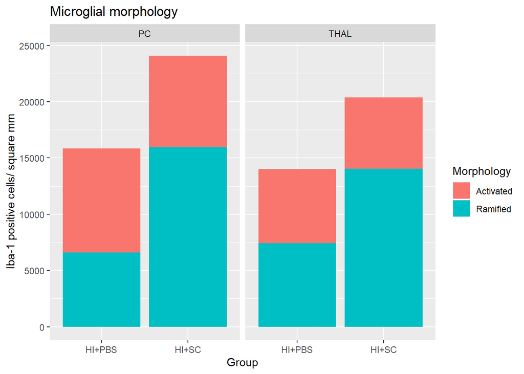

```r
#rename the variables
yIBA$value <- as.numeric(yIBA$value)

zIBA <- rbind(xIBA, yIBA) %>%
  mutate(Morphology = if_else(grepl("Ramified", variable), "Ramified", "Activated"))%>%
  mutate(Morphology = factor(Morphology))%>%
  mutate(Number_of_cells = value)



IBA_summary <- zIBA %>%
  group_by(Group, Morphology) %>%
  summarise(min(Number_of_cells), mean(Number_of_cells), median(Number_of_cells), max(Number_of_cells), sd(Number_of_cells))



plot <- ggplot(zIBA, aes(x = Group, y = Number_of_cells, fill = Morphology))+
  geom_bar(stat = "identity")+
   ggtitle(paste('Microglial morphology'))+
  ylab("Iba-1 positive cells/ square mm")+
  xlab("Group")+
  facet_wrap(~ Region)


print(plot)
```

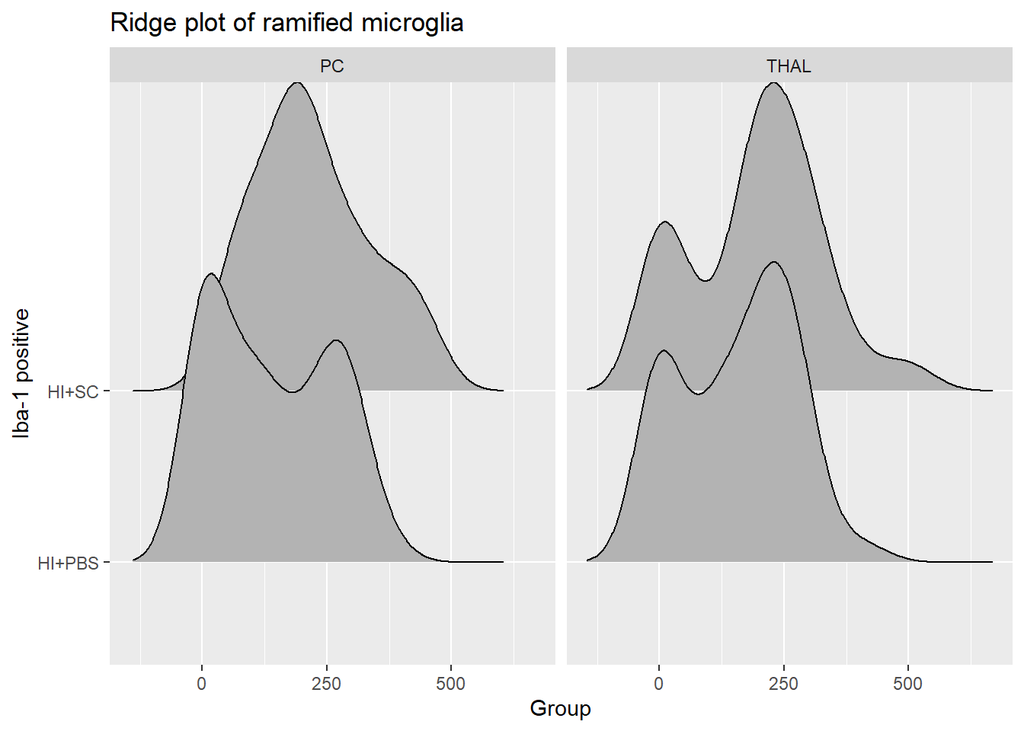

```r
plot <- ggplot(xIBA, aes(x = xIBA$value, y = xIBA$Group))+
  geom_density_ridges()+
  ggtitle(paste('Ridge plot of ramified microglia'))+
  ylab("Iba-1 positive")+
  xlab("Group")+
  facet_wrap(~xIBA$Region)

print(plot)
```

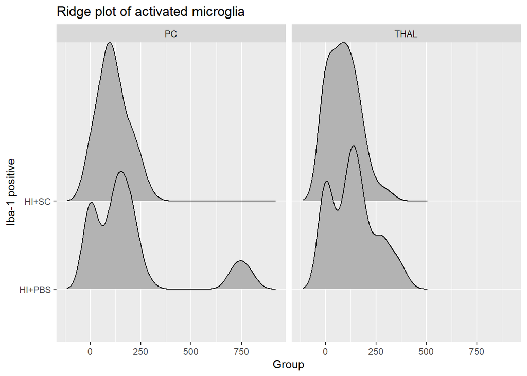

```r
plot <- ggplot(yIBA, aes(x = yIBA$value, y = yIBA$Group))+
  geom_density_ridges()+
  ggtitle(paste('Ridge plot of activated microglia'))+
  ylab("Iba-1 positive")+
  xlab("Group")+
facet_wrap(~yIBA$Region)

print(plot)
```

```r
## The following section explore the data, the major questions to be answered are:
# 1) Does the data meet the assumptions of t-test and anova. Normality, homoscedascity, equal variance?
# 2) Does the data need to be somehow normalised due to batch effects, litter effects, sex effects etc.


#The following series of for loops create new dataframes based on region in preparation for visualisation of batch effects
for (i in seq_along(Microscopy)){
  PC <- Microscopy[[i]] %>%
    filter(Microscopy[[i]]$Region == "PC" )

  i = i+1
}

for (i in seq_along(Microscopy)){
  THAL <- Microscopy[[i]] %>%
    filter(Microscopy[[i]]$Region == "THAL" )

  i = i+1
}

for (i in seq_along(Microscopy)){
  CA1 <- Microscopy[[i]] %>%
    filter(Microscopy[[i]]$Region == "CA1" )

  i = i+1
}

for (i in seq_along(Microscopy)){
  SCWM <- Microscopy[[i]] %>%
    filter(Microscopy[[i]]$Region == "SCWM" )

  i = i+1
}

for (i in seq_along(Microscopy)){
  IGWM <- Microscopy[[i]] %>%
    filter(Microscopy[[i]]$Region == "IGWM" )

  i = i+1
}

for (i in seq_along(Microscopy)){
  PVWM <- Microscopy[[i]] %>%
    filter(Microscopy[[i]]$Region == "PVWM" )

  i = i+1
}
```

# Data

```r
## Neurobehaviour timeseries
HI_SC_NB <- read_excel("Copy of HI+SC_Piglet_master_file.xlsx", sheet = "Neurobehaviour_long", na = "NA")
HI_SC_NB$Group <- factor(HI_SC_NB$Group)

#HI_SC_NB[HI_SC_NB$Group == "3"] <- "SHAM+SC"
#HI_SC_NB$Group[HI_SC_NB$Group == "2"] <- "HI+SC"
#HI_SC_NB$Group[HI_SC_NB$Group == "1"] <- "HI+PBS"
```

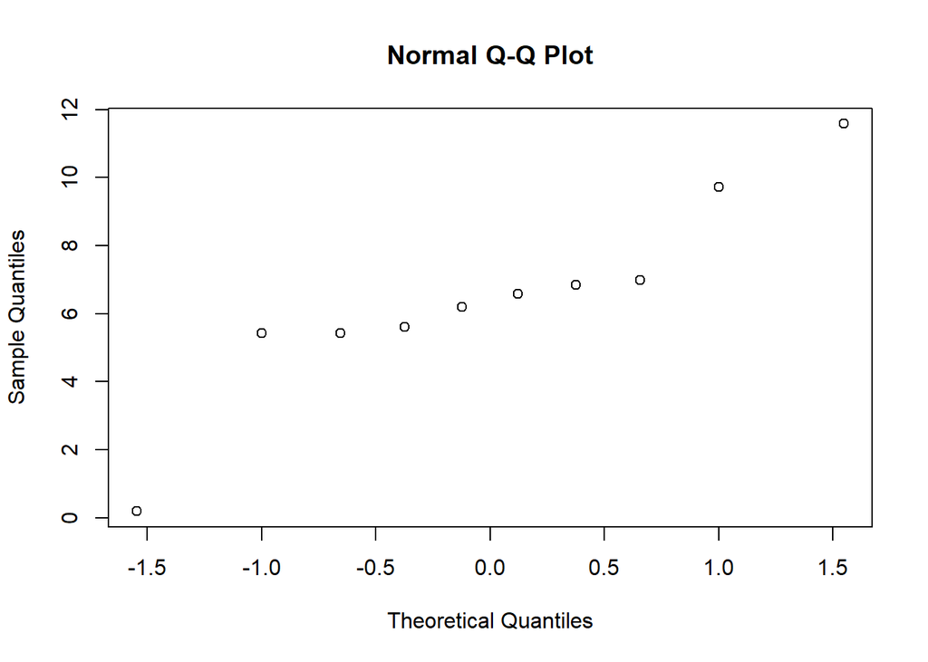

```r
# The goal of this section is to clearly present the underlying relationships between variables and the correlation between measures in relation to the outcome variables.
##Import master file and data
MR <- read_excel("Copy of HI+SC_Piglet_master_file.xlsx",
                 sheet = "MR_data", range = "A2:V20", col_names = TRUE, na = "NA")


MRS <- MR %>%
  select(Pig, Group, `NAA/Cho`, `NAA/Cr`, `NAA/Lac`, `Lac/Cho`, `Lac/Cr`, `Lac/NAA`, `Cho/Cr`) %>%
  mutate(Group = ifelse(Group == 1, "HI+PBS", "HI+SC"))%>%
  mutate(Group = factor(Group))%>%
  na.omit(MR)


MRSl <- c("NAA/Lac","NAA/Cho", "NAA/Cr", "Lac/Cr", "Lac/Cho", "Lac/NAA", "Cho/Cr")

        MRIl <-c("L-T2","R-T2", "L-ADC", "R-ADC", "T2 Value (ms)", "ADC value (mm~^2/s)")




qqnorm(MR$`NAA/Lac`)
```

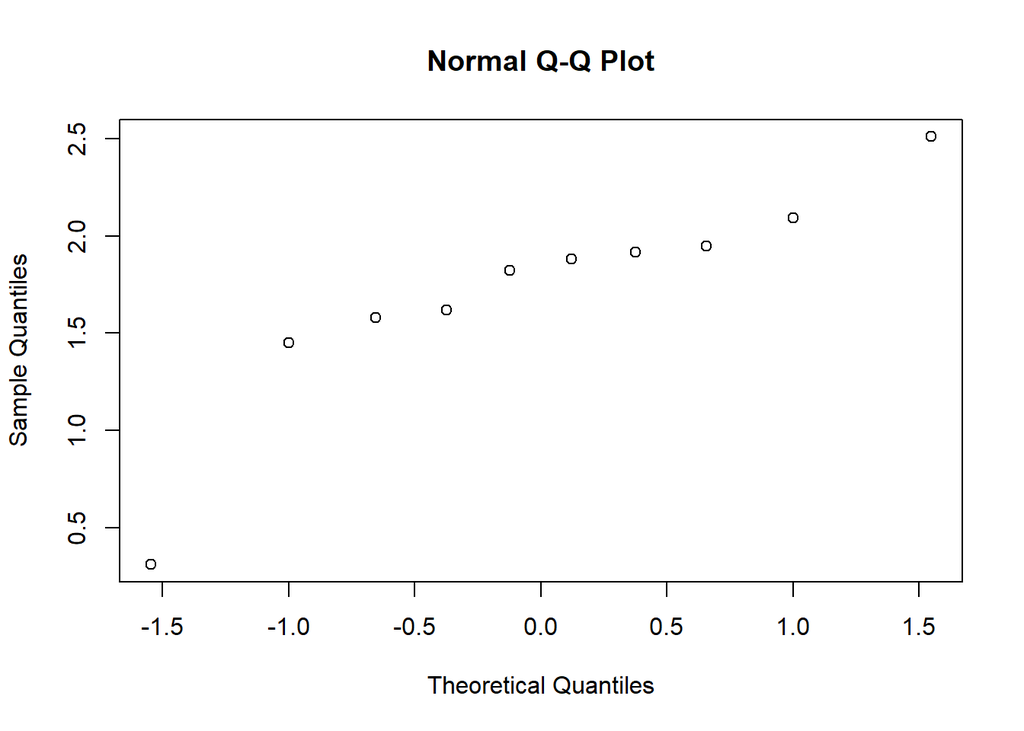

```r
qqnorm(MR$`NAA/Cho`)
```

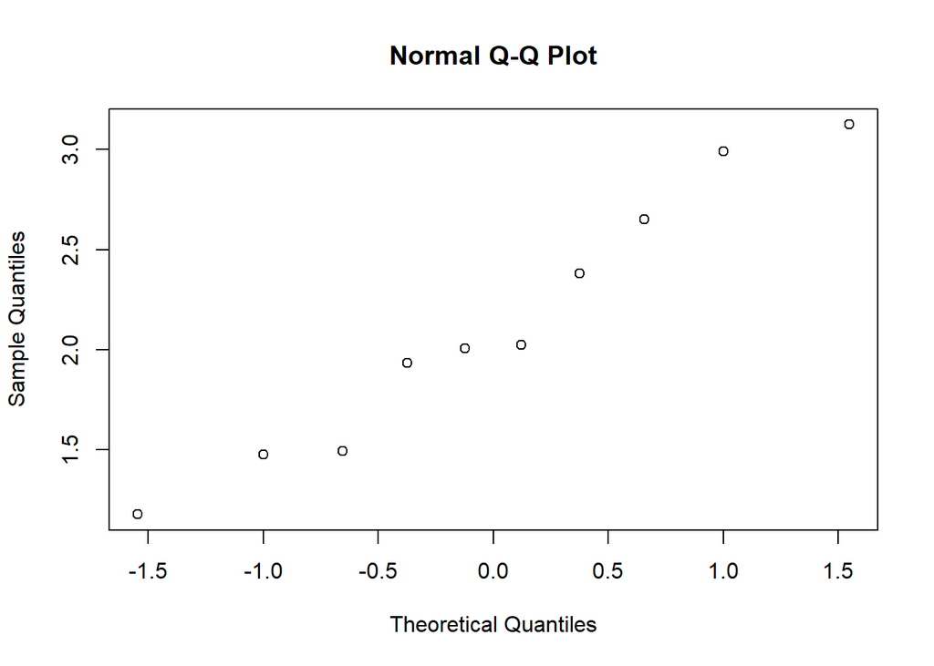

```r
qqnorm(MR$`NAA/Cr`)
```

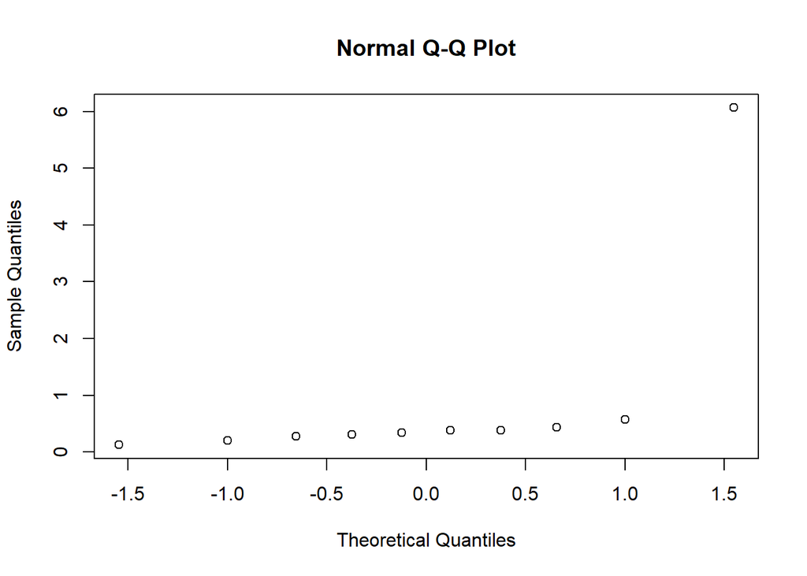

```r
qqnorm(MR$`Lac/Cr`)
```

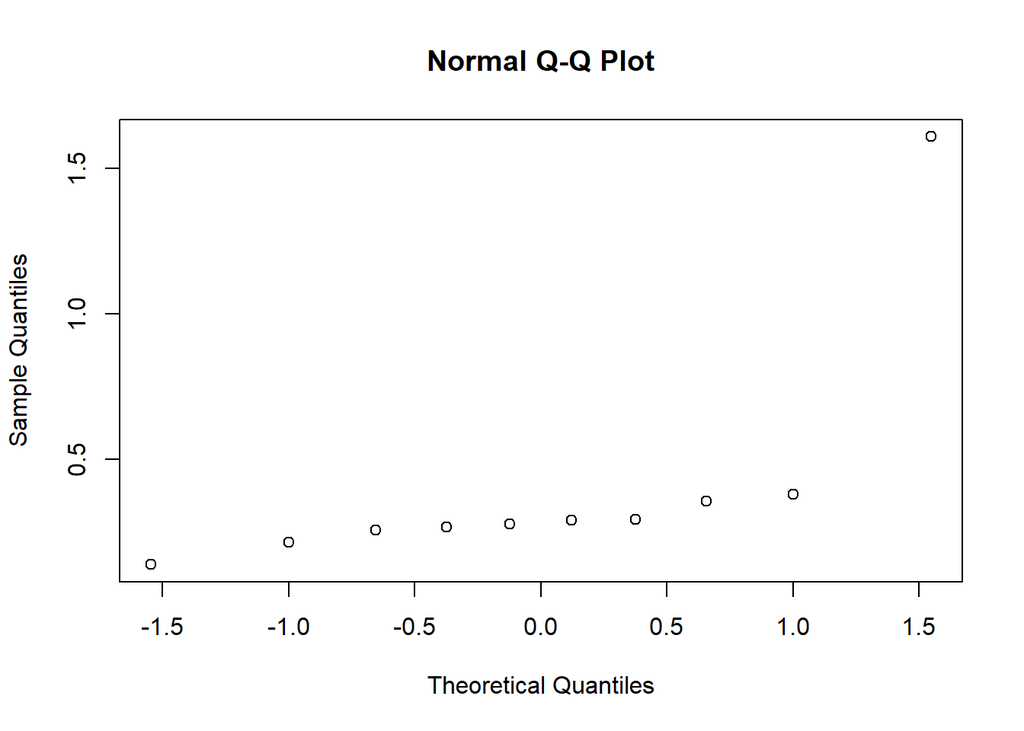

```r
qqnorm(MR$`Lac/Cho`)
```

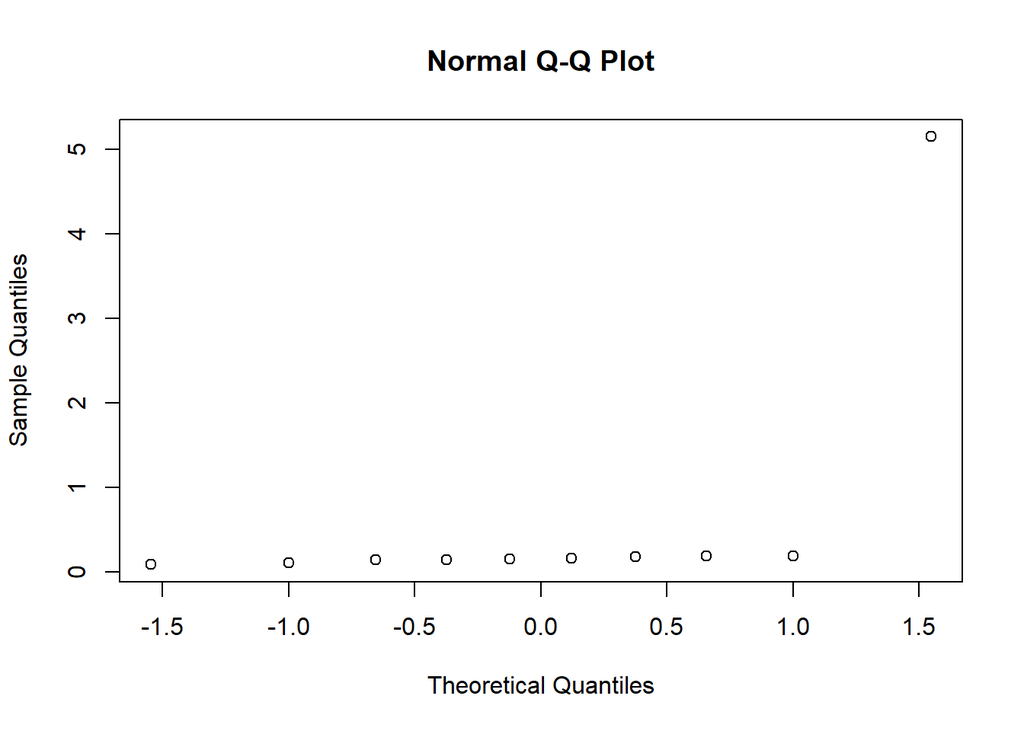

```r
qqnorm(MR$`Lac/NAA`)
```

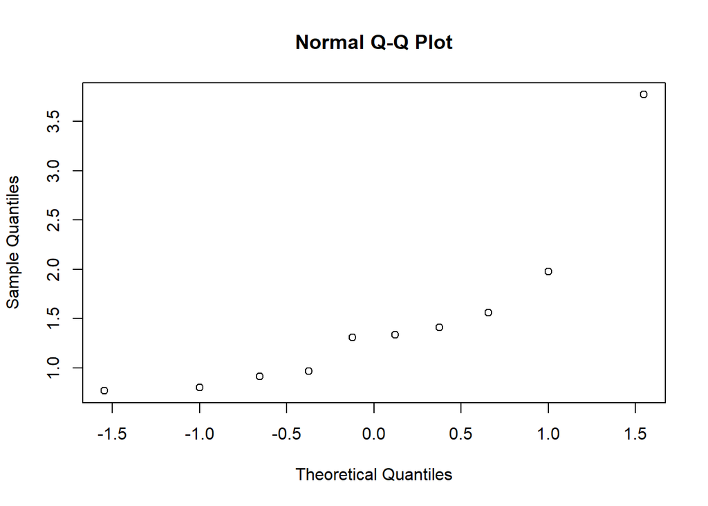

```r
qqnorm(MR$`Cho/Cr`)
```

```r
naa_lac.f.test <- var.test(MR$`NAA/Lac` ~ MR$Group, data = MR)
naa_cho.f.test <- var.test(MR$`NAA/Cho` ~ MR$Group, data = MR)
naa_cr.f.test <- var.test(MR$`NAA/Cr` ~ MR$Group, data = MR)
lac_cr.f.test <- var.test(MR$`Lac/Cr` ~ MR$Group, data = MR)
lac_cho.f.test <- var.test(MR$`Lac/Cho` ~ MR$Group, data = MR)
lac_naa.f.test <- var.test(MR$`Lac/NAA` ~ MR$Group, data = MR)
cr_cho.f.test <- var.test(MR$`Cho/Cr` ~ MR$Group, data = MR)





naa_lac <- t.test(MR$`NAA/Lac` ~ MR$Group, data = MR)
naa_cho <- t.test(MR$`NAA/Cho` ~ MR$Group, data = MR)
naa_cr <- t.test(MR$`NAA/Cr` ~ MR$Group, data = MR)
lac_cr <- t.test(MR$`Lac/Cr` ~ MR$Group, data = MR)
lac_cho <- t.test(MR$`Lac/Cho` ~ MR$Group, data = MR)
lac_naa <- t.test(MR$`Lac/NAA` ~ MR$Group, data = MR)
cr_cho <- t.test(MR$`Cho/Cr` ~ MR$Group, data = MR)


print(naa_lac.f.test)
```

```
##
##  F test to compare two variances
##
## data:  MR$`NAA/Lac` by MR$Group
## F = 8.7045, num df = 3, denom df = 5, p-value = 0.03968
## alternative hypothesis: true ratio of variances is not equal to 1
## 95 percent confidence interval:
##    1.121196 129.564990
## sample estimates:
## ratio of variances
##           8.704503
```

```r
print(naa_cho.f.test)
```

```
##
##  F test to compare two variances
##
## data:  MR$`NAA/Cho` by MR$Group
## F = 4.9605, num df = 3, denom df = 5, p-value = 0.117
## alternative hypothesis: true ratio of variances is not equal to 1
## 95 percent confidence interval:
##   0.6389383 73.8354836
## sample estimates:
## ratio of variances
##           4.960454
```

```r
print(naa_cr.f.test)
```

```
##
##  F test to compare two variances
##
## data:  MR$`NAA/Cr` by MR$Group
## F = 1.0481, num df = 3, denom df = 5, p-value = 0.8958
## alternative hypothesis: true ratio of variances is not equal to 1
## 95 percent confidence interval:
##   0.1349986 15.6003970
## sample estimates:
## ratio of variances
##           1.048074
```

```r
print(lac_naa.f.test)
```

```
##
##  F test to compare two variances
##
## data:  MR$`Lac/NAA` by MR$Group
## F = 6929.1, num df = 3, denom df = 5, p-value = 3.653e-09
## alternative hypothesis: true ratio of variances is not equal to 1
## 95 percent confidence interval:
##     892.5163 103138.8755
## sample estimates:
## ratio of variances
##            6929.13
```

```r
print(lac_cr.f.test)
```

```
##
##  F test to compare two variances
##
## data:  MR$`Lac/Cr` by MR$Group
## F = 487.77, num df = 3, denom df = 5, p-value = 2.754e-06
## alternative hypothesis: true ratio of variances is not equal to 1
## 95 percent confidence interval:
##    62.82853 7260.44329
## sample estimates:
## ratio of variances
##           487.7749
```

```r
print(lac_cho.f.test)
```

```
##
##  F test to compare two variances
##
## data:  MR$`Lac/Cho` by MR$Group
## F = 136.46, num df = 3, denom df = 5, p-value = 6.488e-05
## alternative hypothesis: true ratio of variances is not equal to 1
## 95 percent confidence interval:
##    17.57687 2031.17651
## sample estimates:
## ratio of variances
##           136.4596
```

```r
print(cr_cho.f.test)
```

```
##
##  F test to compare two variances
##
## data:  MR$`Cho/Cr` by MR$Group
## F = 7.342, num df = 3, denom df = 5, p-value = 0.05587
## alternative hypothesis: true ratio of variances is not equal to 1
## 95 percent confidence interval:
##    0.9456944 109.2841207
## sample estimates:
## ratio of variances
##           7.341983
```

```r
print(naa_lac)
```

```
##
##  Welch Two Sample t-test
##
## data:  MR$`NAA/Lac` by MR$Group
## t = -0.25079, df = 3.4649, p-value = 0.8161
## alternative hypothesis: true difference in means is not equal to 0
## 95 percent confidence interval:
##  -7.796311  6.576109
## sample estimates:
## mean in group 1 mean in group 2
##        6.091128        6.701229
```

```r
print(naa_cho)
```

```
##
##  Welch Two Sample t-test
##
## data:  MR$`NAA/Cho` by MR$Group
## t = -1.7938, df = 3.8192, p-value = 0.1507
## alternative hypothesis: true difference in means is not equal to 0
## 95 percent confidence interval:
##  -1.7040053  0.3815888
## sample estimates:
## mean in group 1 mean in group 2
##        1.315743        1.976951
```

```r
print(naa_cr)
```

```
##
##  Welch Two Sample t-test
##
## data:  MR$`NAA/Cr` by MR$Group
## t = -1.2815, df = 6.4617, p-value = 0.2441
## alternative hypothesis: true difference in means is not equal to 0
## 95 percent confidence interval:
##  -1.5118065  0.4607922
## sample estimates:
## mean in group 1 mean in group 2
##        1.811327        2.336834
```

```r
print(lac_naa)
```

```
##
##  Welch Two Sample t-test
##
## data:  MR$`Lac/NAA` by MR$Group
## t = 0.98461, df = 3.0006, p-value = 0.3974
## alternative hypothesis: true difference in means is not equal to 0
## 95 percent confidence interval:
##  -2.753473  5.220917
## sample estimates:
## mean in group 1 mean in group 2
##       1.3887979       0.1550761
```

```r
print(lac_cr)
```

```
##
##  Welch Two Sample t-test
##
## data:  MR$`Lac/Cr` by MR$Group
## t = 0.94345, df = 3.0082, p-value = 0.4149
## alternative hypothesis: true difference in means is not equal to 0
## 95 percent confidence interval:
##  -3.234202  5.965803
## sample estimates:
## mean in group 1 mean in group 2
##       1.7298814       0.3640807
```

```r
print(lac_cho)
```

```
##
##  Welch Two Sample t-test
##
## data:  MR$`Lac/Cho` by MR$Group
## t = 0.76297, df = 3.0293, p-value = 0.5005
## alternative hypothesis: true difference in means is not equal to 0
## 95 percent confidence interval:
##  -0.837223  1.369066
## sample estimates:
## mean in group 1 mean in group 2
##       0.5691066       0.3031851
```

```r
print(cr_cho)
```

```
##
##  Welch Two Sample t-test
##
## data:  MR$`Cho/Cr` by MR$Group
## t = 0.92725, df = 3.552, p-value = 0.4124
## alternative hypothesis: true difference in means is not equal to 0
## 95 percent confidence interval:
##  -1.347456  2.601318
## sample estimates:
## mean in group 1 mean in group 2
##        1.857401        1.230469
```